# Supervised Learning - Foundations Project: ReCell

## Problem Statement

### Business Context

Buying and selling used phones and tablets used to be something that happened on a handful of online marketplace sites. But the used and refurbished device market has grown considerably over the past decade, and a new IDC (International Data Corporation) forecast predicts that the used phone market would be worth \$52.7bn by 2023 with a compound annual growth rate (CAGR) of 13.6% from 2018 to 2023. This growth can be attributed to an uptick in demand for used phones and tablets that offer considerable savings compared with new models.

Refurbished and used devices continue to provide cost-effective alternatives to both consumers and businesses that are looking to save money when purchasing one. There are plenty of other benefits associated with the used device market. Used and refurbished devices can be sold with warranties and can also be insured with proof of purchase. Third-party vendors/platforms, such as Verizon, Amazon, etc., provide attractive offers to customers for refurbished devices. Maximizing the longevity of devices through second-hand trade also reduces their environmental impact and helps in recycling and reducing waste. The impact of the COVID-19 outbreak may further boost this segment as consumers cut back on discretionary spending and buy phones and tablets only for immediate needs.

### Objective

The rising potential of this comparatively under-the-radar market fuels the need for an ML-based solution to develop a dynamic pricing strategy for used and refurbished devices. ReCell, a startup aiming to tap the potential in this market, has hired you as a data scientist. They want you to analyze the data provided and build a linear regression model to predict the price of a used phone/tablet and identify factors that significantly influence it.

### Data Description

The data contains the different attributes of used/refurbished phones and tablets. The data was collected in the year 2021. The detailed data dictionary is given below.

- brand_name: Name of manufacturing brand
- os: OS on which the device runs
- screen_size: Size of the screen in cm
- 4g: Whether 4G is available or not
- 5g: Whether 5G is available or not
- main_camera_mp: Resolution of the rear camera in megapixels
- selfie_camera_mp: Resolution of the front camera in megapixels
- int_memory: Amount of internal memory (ROM) in GB
- ram: Amount of RAM in GB
- battery: Energy capacity of the device battery in mAh
- weight: Weight of the device in grams
- release_year: Year when the device model was released
- days_used: Number of days the used/refurbished device has been used
- normalized_new_price: Normalized price of a new device of the same model in euros
- normalized_used_price: Normalized price of the used/refurbished device in euros

## Importing necessary libraries

```python
# Libraries for reading and manipulating data
import numpy as np
import pandas as pd

# Libraries for  data visualization
import matplotlib.pyplot as plt
import seaborn as sns

# Library to build Linear Regression Model
import statsmodels.api as sm

# Libraries for spliting  data into train and test and to check model performance
from sklearn.model_selection import train_test_split
from sklearn.metrics import mean_absolute_error, mean_squared_error, r2_score

#Define number of columns for the dataframe to be displayed
pd.set_option('display.max_columns', None)

# Set Seaborn aesthetic parameters
sns.set(
    context='notebook',
    style='darkgrid',
    #palette="Blues",
    font='sans-serif',
    font_scale=1.2,
    rc={'figure.figsize': (10, 6)}
)

# Suppress warnings
import warnings
warnings.filterwarnings('ignore')
```

## Loading the dataset

```python
#Mount Google Drive for loading dataset
from google.colab import drive
drive.mount('/content/drive')
```

```python
#Loading dataset "used_device_data.csv" and preview it
uddf = pd.read_csv('/content/drive/MyDrive/Colab Notebooks/Supervised Learning - Foundations/Project/used_device_data.csv')
uddf.head()
```

|  | brand_name | os | screen_size | 4g | 5g | main_camera_mp | selfie_camera_mp | int_memory | ram | battery | weight | release_year | days_used | normalized_used_price | normalized_new_price |
| --- | --- | --- | --- | --- | --- | --- | --- | --- | --- | --- | --- | --- | --- | --- | --- |
| 0 | Honor | Android | 14.50 | yes | no | 13.0 | 5.0 | 64.0 | 3.0 | 3020.0 | 146.0 | 2020 | 127 | 4.307572 | 4.715100 |
| 1 | Honor | Android | 17.30 | yes | yes | 13.0 | 16.0 | 128.0 | 8.0 | 4300.0 | 213.0 | 2020 | 325 | 5.162097 | 5.519018 |
| 2 | Honor | Android | 16.69 | yes | yes | 13.0 | 8.0 | 128.0 | 8.0 | 4200.0 | 213.0 | 2020 | 162 | 5.111084 | 5.884631 |
| 3 | Honor | Android | 25.50 | yes | yes | 13.0 | 8.0 | 64.0 | 6.0 | 7250.0 | 480.0 | 2020 | 345 | 5.135387 | 5.630961 |
| 4 | Honor | Android | 15.32 | yes | no | 13.0 | 8.0 | 64.0 | 3.0 | 5000.0 | 185.0 | 2020 | 293 | 4.389995 | 4.947837 |

## Data Overview

```python
#Show shape of the dataframe, its rows and columns
usp = uddf.shape
print(f'The used devices dataset has \033[1m{usp[0]}\033[0m rows and \033[1m{usp[1]}\033[0m columns.\n')
```

```
The used devices dataset has 3454 rows and 15 columns.
```

```python
#Show dataset columns with along with its datatype
print('\033[1m'+'Find below dataset information:'+'\033[0m')
uddf.info()
```

```
Find below dataset information:
<class 'pandas.core.frame.DataFrame'>
RangeIndex: 3454 entries, 0 to 3453
Data columns (total 15 columns):
 #   Column                 Non-Null Count  Dtype
---  ------                 --------------  -----
 0   brand_name             3454 non-null   object
 1   os                     3454 non-null   object
 2   screen_size            3454 non-null   float64
 3   4g                     3454 non-null   object
 4   5g                     3454 non-null   object
 5   main_camera_mp         3275 non-null   float64
 6   selfie_camera_mp       3452 non-null   float64
 7   int_memory             3450 non-null   float64
 8   ram                    3450 non-null   float64
 9   battery                3448 non-null   float64
 10  weight                 3447 non-null   float64
 11  release_year           3454 non-null   int64
 12  days_used              3454 non-null   int64
 13  normalized_used_price  3454 non-null   float64
 14  normalized_new_price   3454 non-null   float64
dtypes: float64(9), int64(2), object(4)
memory usage: 404.9+ KB
```

### Observations:

- **Categorical columns:** There are **4 columns** with datatype '**object**' (brand_name, os, 4g, 5g).
- **Numerical columns:** **2 columns** have datatype '**int64**' (release_year & days_used) and **9 columns** with datatype '**float64**' (screen_size, main_camera_mp, selfie_camera_mp, int_memory, ram, battery, weight, normalized_used_price, normalized_new_price).
- **Memory usage:** This dataframe uses 404.9 KB of memory.

```python
#Describes the numeric fields, highlighting the non-null count, mean, standard deviation, Minimum, Maximum, 25%, 50% and 75% values.
print(f'\033[1mStatistics for all numeric columns:\033[0m')
uddf.describe().T
```

```
Statistics for all numeric columns:
```

|  | count | mean | std | min | 25% | 50% | 75% | max |
| --- | --- | --- | --- | --- | --- | --- | --- | --- |
| screen_size | 3454.0 | 13.713115 | 3.805280 | 5.080000 | 12.700000 | 12.830000 | 15.340000 | 30.710000 |
| main_camera_mp | 3275.0 | 9.460208 | 4.815461 | 0.080000 | 5.000000 | 8.000000 | 13.000000 | 48.000000 |
| selfie_camera_mp | 3452.0 | 6.554229 | 6.970372 | 0.000000 | 2.000000 | 5.000000 | 8.000000 | 32.000000 |
| int_memory | 3450.0 | 54.573099 | 84.972371 | 0.010000 | 16.000000 | 32.000000 | 64.000000 | 1024.000000 |
| ram | 3450.0 | 4.036122 | 1.365105 | 0.020000 | 4.000000 | 4.000000 | 4.000000 | 12.000000 |
| battery | 3448.0 | 3133.402697 | 1299.682844 | 500.000000 | 2100.000000 | 3000.000000 | 4000.000000 | 9720.000000 |
| weight | 3447.0 | 182.751871 | 88.413228 | 69.000000 | 142.000000 | 160.000000 | 185.000000 | 855.000000 |
| release_year | 3454.0 | 2015.965258 | 2.298455 | 2013.000000 | 2014.000000 | 2015.500000 | 2018.000000 | 2020.000000 |
| days_used | 3454.0 | 674.869716 | 248.580166 | 91.000000 | 533.500000 | 690.500000 | 868.750000 | 1094.000000 |
| normalized_used_price | 3454.0 | 4.364712 | 0.588914 | 1.536867 | 4.033931 | 4.405133 | 4.755700 | 6.619433 |
| normalized_new_price | 3454.0 | 5.233107 | 0.683637 | 2.901422 | 4.790342 | 5.245892 | 5.673718 | 7.847841 |

### Observations:

```python
#Describes categoriacal fields, shows the count of non-null values, unique value count, top (most records with the value) and frequency.
print(f'\033[1mStatistics for all categorical columns:\033[0m')
uddf.describe(include='object').T
```

```
Statistics for all categorical columns:
```

|  | count | unique | top | freq |
| --- | --- | --- | --- | --- |
| brand_name | 3454 | 34 | Others | 502 |
| os | 3454 | 4 | Android | 3214 |
| 4g | 3454 | 2 | yes | 2335 |
| 5g | 3454 | 2 | no | 3302 |

### Observations:

- **brand_name:** 34 unique brands, with 'Others' being the most frequent with 502 devices.
- **os:** 4 unique operating systems, with 'Android' being the predominant OS 3214 (93%) devices.
- **4g:** Two categories - 'yes' and 'no', most devices are 4g enabled, 2335 (68%).
- **5g:** Two categories - 'yes' and 'no', most devices does not have 5g feature, 3302 (96%).

## Exploratory Data Analysis (EDA)

**Refer to Appendix section for detailed EDA**

- EDA is an important part of any project involving data.
- It is important to investigate and understand the data better before building a model with it.
- A few questions have been mentioned below which will help you approach the analysis in the right manner and generate insights from the data.
- A thorough analysis of the data, in addition to the questions mentioned below, should be done.

### Functions to plot charts

In this section, several functions have been meticulously defined to streamline the process of Exploratory Data Analysis (EDA). Each function is tailored to visualize and analyze different aspects of the dataset. Here's a concise documentation of each function:

**plot_numerical(dataframe):**

- **Purpose:** Facilitates Univariate analysis.
- **Description:** Automatically identifies numerical variables in the provided dataframe and generates subplots that include a boxplot and a histogram for each numerical variable. These visualizations aid in understanding the distribution and identifying potential outliers.

**plot_categorical(dataframe):**

- **Purpose:** Facilitates Univariate analysis.
- **Description:** Identifies categorical variables within the given dataframe and generates subplots with countplots for each categorical variable. This function is essential for visualizing the frequency distribution of categorical data.

**plot_box_hist_ind(dataframe, column, title):**

- **Purpose:** Conducts Univariate analysis on a single variable.
- **Description:** Creates a combined visualization consisting of a box plot and a histogram for the specified column in the dataframe. This dual representation provides a comprehensive view of the distribution, central tendency, and variability of the data.

**plot_countplot_ind(dataframe, column, title, labeltype):**

- **Purpose:** Facilitates Univariate analysis.
- **Description:** Generates a countplot for the specified variable, with the option to display data labels as values, percentages, or both. This function is instrumental in visualizing the count of occurrences of each category in a variable.

**plot_box_bar(dataframe, x_var, y_var, chart_title):**

- **Purpose:** Aids in Bivariate analysis.
- **Description:** Constructs a boxplot and a barplot side by side for two specified variables, allowing for a detailed comparison and relationship assessment between the variables. This function is particularly useful for comparing the central tendency and dispersion between groups.

**plot_single_variable_correlation(correlation_series):**

- **Purpose:** Identifies correlations for a target variable.
- **Description:** Takes a series of correlation values as input and generates a bar chart, showcasing the relationship between the target variable and other numerical variables in the dataset. This visualization is critical for understanding how different variables interact with the target variable.

Each function is designed to extract meaningful insights from the dataset, providing a clear and intuitive understanding of the underlying patterns, trends, and relationships.

```python
def plot_numerical(dataframe):
    # Extract numerical variables
    numeric_columns = dataframe.select_dtypes(include=['float64', 'int64']).columns
    num_vars = len(numeric_columns)

    # Calculate the number of rows for the subplot
    num_rows = (num_vars // 3) + (1 if num_vars % 3 != 0 else 0)

    # Set up the matplotlib figure
    fig, axes = plt.subplots(2 * num_rows, 3, figsize=(20, 5 * num_rows * 1.25), constrained_layout=True, gridspec_kw={'height_ratios': [1, 4] * num_rows})

    # Loop through the numerical variables to create boxplots and histograms
    for i, column in enumerate(numeric_columns):
        # Define the row and column index in the subplot grid
        row = (i // 3) * 2
        col = i % 3

        # Create a boxplot for the variable
        sns.boxplot(data=dataframe, x=column, ax=axes[row, col])
        axes[row, col].set_title(f'Box Plot and Histogram for {column}', fontsize=12)
        axes[row, col].tick_params(labelbottom=False)  # Remove x-ticks for the boxplot
        axes[row, col].set_xlabel('')  # Remove x-axis label for the boxplot

        # Create a histogram for the variable
        sns.histplot(data=dataframe, x=column, kde=True, ax=axes[row + 1, col], binwidth=None)
        axes[row + 1, col].set_title('')  # Remove title for the histogram
        axes[row + 1, col].set_xlabel(f'{column}\n\n')  # Set x-axis label for the histogram

    # Remove the excess axes
    i += 1
    delrow =  (i // 3) * 2
    delcol = i % 3
    fig.delaxes(axes[delrow, delcol])
    fig.delaxes(axes[delrow + 1, delcol])

    plt.show()

def plot_categorical(dataframe):
    # Extract categorical variables
    categorical_columns = dataframe.select_dtypes(include=['object', 'category']).columns
    num_vars = len(categorical_columns) - 1  # Excluding 'brand_name'

    # Calculate the number of rows for the FacetGrid-like layout
    num_rows = 1 + (num_vars // 3 + (1 if num_vars % 3 != 0 else 0))

    # Set up the matplotlib figure
    fig, axes = plt.subplots(num_rows, 3, figsize=(20, 5 * num_rows), constrained_layout=True)

    # Flatten the axes array for easy iteration if there are multiple rows
    if axes.ndim > 1:
        axes = axes.flatten()

    # Calculate the counts and sort for 'brand_name'
    order_brand_name = dataframe['brand_name'].value_counts().index
    total_brand_name = len(dataframe['brand_name'])

    # Create a new big subplot for 'brand_name' that spans the first row
    big_ax_brand_name = fig.add_subplot(num_rows, 1, 1)
    brand_name_plot = sns.countplot(x='brand_name', data=dataframe, ax=big_ax_brand_name, order=order_brand_name)
    big_ax_brand_name.set_title('Count of brand_name', fontsize=12)
    big_ax_brand_name.tick_params(axis='x', rotation=90)
    big_ax_brand_name.set_xlabel('')

    # Add data labels for 'brand_name'
    for p in brand_name_plot.patches:
        count = p.get_height()
        percentage = 100 * count / total_brand_name
        axx = p.get_x() + p.get_width() / 2
        axy = p.get_height()
        big_ax_brand_name.annotate(f'{int(count)} ({percentage:.1f}%)', (axx, axy), ha='center', va='bottom', rotation=90)

    # Hide the original axes in the first row
    for ax in axes[:3]:
        ax.remove()

    # Loop through the remaining categorical variables to create count plots
    for i, column in enumerate(categorical_columns[1:], start=1):
        # Define the row and column index in the subplot grid
        row = (i - 1) // 3 + 1  # +1 because the first entire row is for 'brand_name'
        col = (i - 1) % 3
        total = len(dataframe[column])

        # Create countplot
        ax = axes[row * 3 + col]
        plot = sns.countplot(x=column, data=dataframe, ax=ax)
        ax.set_title(f'Count of {column}', fontsize=12)
        ax.tick_params(axis='x')

        # Add data labels
        for p in plot.patches:
            count = p.get_height()
            percentage = 100 * count / total
            axx = p.get_x() + p.get_width() / 2
            axy = p.get_height()
            ax.annotate(f'{int(count)} ({percentage:.1f}%)', (axx, axy), ha='center', va='bottom')

    # Adjust layout
    plt.tight_layout()
    plt.show()

def plot_box_hist_ind(dataframe, column, title):
    """
    Plot a box plot and a histogram for the specified column of the dataframe.

    :param dataframe: pandas DataFrame
    :param column: string, the name of the column to plot
    :param title: string, the title for the plots
    """
    # Set up a grid layout with 2 rows
    fig, ax = plt.subplots(2, 1, figsize=(10, 6), gridspec_kw={'height_ratios': [1, 4]})

    # Plotting the boxplot on the first row
    sns.boxplot(x=dataframe[column], ax=ax[0], color='lightblue')
    ax[0].set_title(f'Box Plot and Histogram for {title}')
    ax[0].tick_params(labelbottom=False)  # Remove x-ticks for the boxplot
    ax[0].set_xlabel('')  # Hide x-axis label for the boxplot

    # Plotting the histogram on the second row
    sns.histplot(dataframe[column], kde=True, color='skyblue', ax=ax[1])

    # Calculate the mean and median
    mean_price = dataframe[column].mean()
    median_price = dataframe[column].median()
    min_price = dataframe[column].min()
    max_price = dataframe[column].max()

    # Add vertical lines for mean, median, min, and max
    ax[1].axvline(mean_price, color='red', linestyle='--', linewidth=1, label=f'Mean: {mean_price:.2f}')
    ax[1].axvline(median_price, color='green', linestyle='-', linewidth=1, label=f'Median: {median_price:.2f}')
    ax[1].axvline(min_price, color='blue', linestyle=':', linewidth=1, label=f'Min: {min_price:.2f}')
    ax[1].axvline(max_price, color='purple', linestyle='-.', linewidth=1, label=f'Max: {max_price:.2f}')

    # Add title and labels for clarity in the histogram
    ax[1].set_title('')  # Hide title for the histogram
    ax[1].set_xlabel(title, fontsize=12)
    ax[1].set_ylabel('Frequency', fontsize=12)

    # Display legends
    ax[1].legend()

    # Adjust layout
    plt.tight_layout()

    # Display the plot
    plt.show()

def plot_countplot_ind(dataframe, column, title, labeltype):
    """
    Plot a countplot for a specified column in the dataframe with value, percentage, value (percentage), or
    value (% to overall count for the brand in uddf) labels.

    Args:
    dataframe (pd.DataFrame): The dataframe containing the data (subset or specific view).
    column (str): The name of the column for which to create the countplot.
    title (str): The title of the plot.
    labeltype (str): Type of label to display ('value', 'percentage', 'valperc', or 'valueoverallperc').
      labeltype = 'value' > Prints count for the variable
      labeltype = 'percentage' > Prints percentage (proportion) of the count
      labeltype = 'valperc' > Prints count as well as percentage of the count
      labeltype = 'valueoverallperc' > Prints count of the filtered dataframe and percentage to count of the original dataframe
    uddf (pd.DataFrame, optional): The original dataframe for comparison if labeltype is 'valueoverallperc'.
    """
    # Set up the figure size
    plt.figure(figsize=(20, 8))

    # Calculate the counts and sort for the column based on the provided dataframe
    order = dataframe[column].value_counts().index

    # Create a countplot for the specified column
    ax = sns.countplot(data=dataframe, x=column, order=order, color='skyblue')

    # Add title and labels for clarity
    plt.title(title)
    plt.xlabel(column)
    plt.ylabel('Count')

    # Define total_devices outside of the loop for efficiency
    total_devices = len(dataframe)

    # Calculate the total number of devices for each category in the overall dataframe if labeltype is 'valueoverallperc'
    if labeltype == 'valueoverallperc':
        overall_totals = uddf[column].value_counts()

    # Add data labels
    for i, p in enumerate(ax.patches):
        height = p.get_height()  # get the height of each bar
        axx = p.get_x() + p.get_width() / 2
        axy = height
        if labeltype == 'value':
            label = f'{int(height)}'
        elif labeltype == 'percentage':
            percentage = 100 * height / total_devices
            label = f'{percentage:.1f}%'
        elif labeltype == 'valperc':
            percentage = 100 * height / total_devices
            label = f'{int(height)} ({percentage:.1f}%)'
        elif labeltype == 'valueoverallperc':
            brand_name = order[i]  # Get the brand name from the order list
            overall_percentage = 100 * height / overall_totals[brand_name]
            label = f'{int(height)} ({overall_percentage:.1f}%)'
        ax.annotate(label, (axx, axy), ha='center', va='bottom', rotation=90)

    # Rotate x-labels for better readability
    plt.xticks(rotation=45)

    # Show the plot
    plt.show()


def plot_box_bar(dataframe, x_var, y_var, chart_title):
    """
    Plot a boxplot and a barplot as subplots to show the distribution and mean of a numerical variable across different categories.

    Args:
    dataframe (pd.DataFrame): The dataframe containing the data.
    x_var (str): The name of the numerical variable.
    y_var (str): The name of the categorical variable.
    chart_title (str): The title of the charts.

    """
    # Set up the figure size and subplots layout
    fig, axes = plt.subplots(2, 1, figsize=(20, 10), gridspec_kw={'height_ratios': [1, 1]})

    # Create a boxplot on the first row
    sns.boxplot(data=dataframe, x=x_var, y=y_var, palette='Blues', ax=axes[0])
    axes[0].set_title(f'Boxplot and Barplot of {chart_title}')
    axes[0].set_xlabel('')  # Hide x-axis label
    axes[0].tick_params(labelbottom=False)  # Remove x-ticks for the boxplot
    axes[0].set_ylabel(y_var)

    # Create a barplot on the second row
    sns.barplot(data=dataframe, x=x_var, y=y_var, palette='Blues', ax=axes[1])
    axes[1].set_title('')  # Hide title
    axes[1].set_xlabel(x_var)
    axes[1].set_ylabel(f'Mean {x_var}')

    # Rotate x-labels for better readability if necessary
    plt.xticks(rotation=45)

    # Adjust layout
    plt.tight_layout()

    # Show the plot
    plt.show()

def plot_single_variable_correlation(correlation_series):
    """
    Plot a vertical bar chart based on the given correlation series using Seaborn, including data labels on the bars.

    Args:
    correlation_series (pd.Series): A series representing the correlation values of a single variable with others.
    """
    # Set the figure size
    plt.figure(figsize=(20, 10))

    # Create a vertical bar chart using Seaborn
    ax = sns.barplot(x=correlation_series.index, y=correlation_series.values, palette="Blues")

    # Add title and labels for clarity
    plt.title('Correlation with Normalized Used Price')
    plt.xlabel('Variables')
    plt.ylabel('Correlation Value')

    # Add data labels
    for p in ax.patches:
        width = p.get_width()
        height = p.get_height()
        plt.text(p.get_x() + width / 2,  # x-coordinate position of data label, to align with the middle of the bar
                 height + 0.01,  # y-coordinate position of data label, padded 0.01 above the bar
                 f'{height:.2f}',  # data label, formatted to 2 decimal places
                 ha='center',  # center alignment
                 va='bottom')  # bottom alignment

    # Rotate x-labels for better readability
    plt.xticks(rotation=45)

    # Show the plot
    plt.show()
```

### Questions and Answers

#### 1. What does the distribution of normalized used device prices look like?

**Ans:** The distribution of normalized used device prices predominantly exhibits a **normal pattern**. However, there are noticeable outliers present at both the lower and upper extremes of the distribution as captured under boxplot.

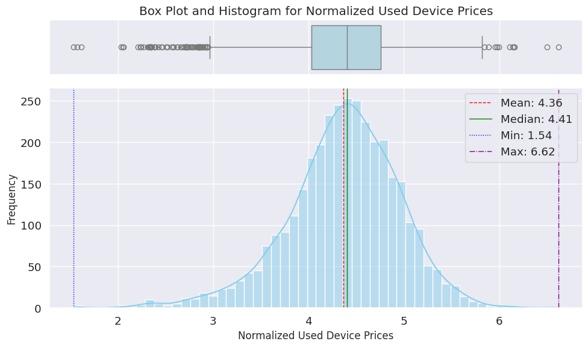

```python
#Plot Box plot and Histogram for Normalized Used Prices using function plot_box_hist_ind()
plot_box_hist_ind(uddf,'normalized_used_price',"Normalized Used Device Prices")
```

#### 2. What percentage of the used device market is dominated by Android devices?

**Ans:** Android holds a commanding presence in the used device market, **encompassing 93.1% (3214 devices) of the total**. This substantial market share may reflect a widespread consumer preference or a broader availability of Android-based devices, underlining its dominance in the sector.

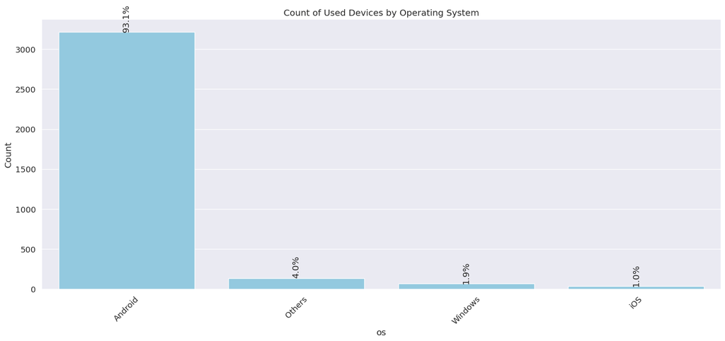

```python
#The function plot_countplot_ind() is invoked to visually represent the answer through a countplot.
plot_countplot_ind(uddf,'os',"Count of Used Devices by Operating System",'percentage')
```

#### 3. The amount of RAM is important for the smooth functioning of a device. How does the amount of RAM vary with the brand?

**Ans:** RAM allocation **varies significantly** across brands, with each brand exhibiting a unique distribution pattern as evident from the box plots.

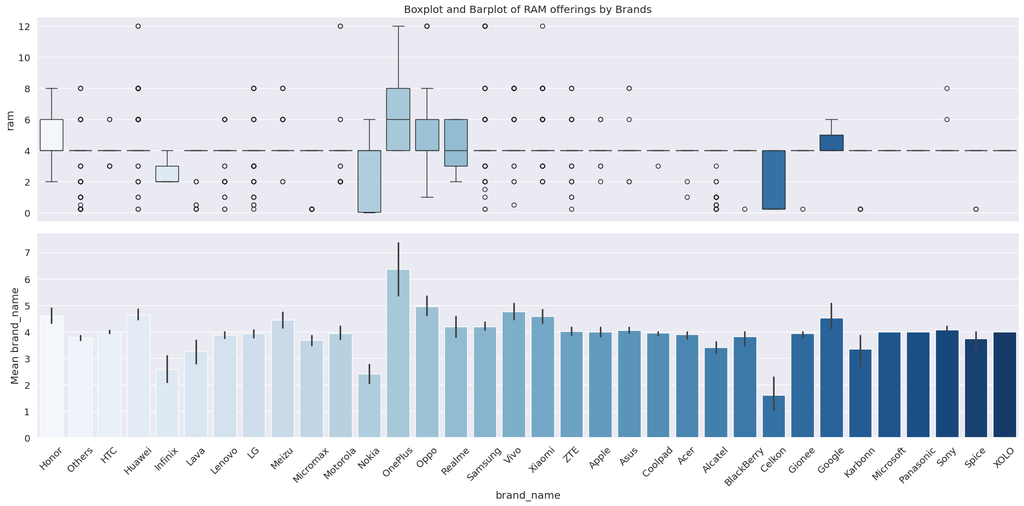

```python
# Box plot to illustrate RAM offerings by Brands.
plot_box_bar(uddf,'brand_name','ram',"RAM offerings by Brands")
```

```python
# Filter for devices with 4 GB RAM
devices_with_4gb_ram = uddf[uddf['ram'] == 4]

# Calculate total count of devices with 4 GB RAM
total_count_4gb_ram = devices_with_4gb_ram.shape[0]

# Calculate total count of devices
total_devices = uddf.shape[0]

# Calculate percentage of total devices with 4 GB RAM
percentage_4gb_ram = (total_count_4gb_ram / total_devices) * 100

# Count of brand_name with devices with 4 GB RAM
brand_count_with_4gb_ram = devices_with_4gb_ram['brand_name'].nunique()

print(f'Total count of devices with 4 GB RAM: {total_count_4gb_ram}')
print(f'Percentage of total devices with 4 GB RAM: {percentage_4gb_ram:.2f}%')
print(f'Count of brand_name with devices with 4 GB RAM: {brand_count_with_4gb_ram}')
```

```
Total count of devices with 4 GB RAM: 2815
Percentage of total devices with 4 GB RAM: 81.50%
Count of brand_name with devices with 4 GB RAM: 34
```

#### 4. A large battery often increases a device's weight, making it feel uncomfortable in the hands. How does the weight vary for phones and tablets offering large batteries (more than 4500 mAh)?

**Ans:** Upon analyzing the weight distribution of devices with battery capacities greater than 4500 mAh, the following key observations were made:

- The weight of devices varies notably across different brands, showcasing a diverse range of device weights in the market.
- The weight distributions are not uniformly normal for most brands, suggesting a wide spread of device weights within individual brands.
- Several brands exhibit outliers in their weight distributions, indicating the existence of exceptionally heavy or light devices within those brands.
- Specifically, Google's devices are the heaviest on average, with a mean weight of approximately 517 grams, while Micromax devices are the lightest, averaging around 118 grams.
- The provided boxplot effectively illustrates these weight variations among brands, clearly depicting the median, quartiles, and outliers for each brand's device weights.

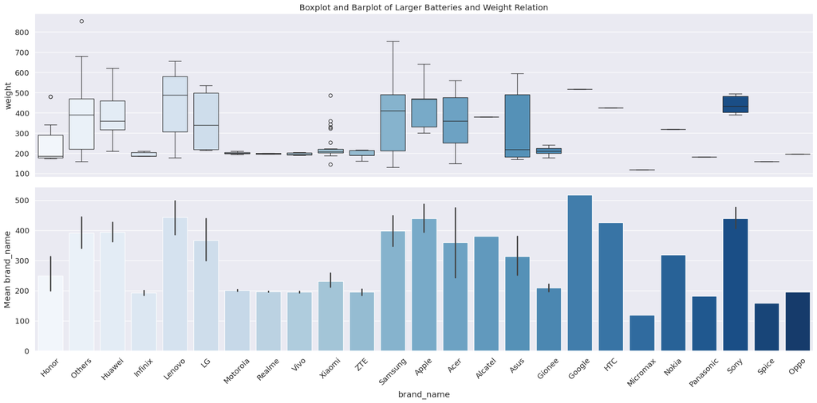

```python
#Use plot_box_bar() function to identify weight variance for devices offering larger batteries (> 4500 mAh).
uddf_largebatteries = uddf[uddf['battery']>4500]
plot_box_bar(uddf_largebatteries,'brand_name','weight','Larger Batteries and Weight Relation')
```

#### 5. Bigger screens are desirable for entertainment purposes as they offer a better viewing experience. How many phones and tablets are available across different brands with a screen size larger than 6 inches?

Ans: 1,099 (31.82%) out of 3454 devices have a screen size larger than 6 inches (15.24 cms), indicating that a significant portion of the market offers larger screen devices. Following are the other key observations:

- **Strong Presence in Niche Brands:** Infinix (100%) and Realme (97%) lead with all or nearly all of their devices featuring screens larger than 6 inches, highlighting a strong market presence in this segment.
- **Significant Offering by Major Brands:** OnePlus (72%), Vivo (68%), Honor (62%), Apple (62%), and Huawei (59%) have a substantial portion of their product lineup with larger screens, reflecting their commitment to catering to the consumer preference for bigger displays.
- **Moderate Presence in Established Brands:** Brands like Samsung (35%), Xiaomi (52%), Lenovo (40%), and LG (29%) offer a moderate selection of larger screen devices, balancing their portfolio to cater to diverse consumer needs.
- **Minimal or No Large Screen Devices in Certain Brands:** Brands like Celkon, BlackBerry, and Lava currently do not offer devices with screens larger than 15.24 cm, possibly focusing on other features or market segments.
- **Market Share**: Huawei and Samsung lead the large device market segment with 149 and 119 devices over 6 inches.

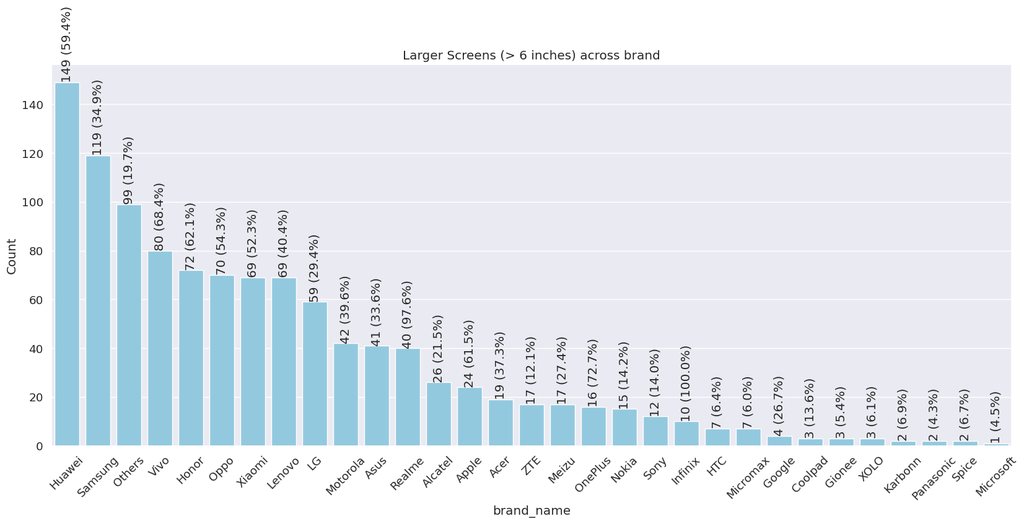

```python
# Create a subset of dataframe to analyze data related to screens larger than 6 inches
uddf_largescreens = uddf[uddf['screen_size']> (6 * 2.54)] #converting inches to cm, as screen_size is availble in CMs.

#Use plot_countplot_ind() function to understand brands' preference on larger screen size, > 6 inches.
plot_countplot_ind(uddf_largescreens,'brand_name','Larger Screens (> 6 inches) across brand','valueoverallperc')

#Data labels display the count and the percentage of each brand's own devices featuring screens bigger than 6 inches.
```

#### 6. A lot of devices nowadays offer great selfie cameras, allowing us to capture our favorite moments with loved ones. What is the distribution of devices offering greater than 8MP selfie cameras across brands?

**Ans:** Out of 3,454 devices, 655 (18.96%) offer selfie cameras above 8MP. While this is a considerable number, it may not necessarily indicate a predominant focus across all brands.

- **Brands with Segment Focus:** OnePlus, Vivo and Oppo have significant portion of devices focusing on market with need for large MP selfie cameras.
- **Device offerings:** Brands such as Huawei, Vivo, Oppo, Xiaomi and Samsung lead the table and offer more than 50 devices with selfie cameras larger than 8 MP.
- A small segment of devices (39), have no selfie camera.

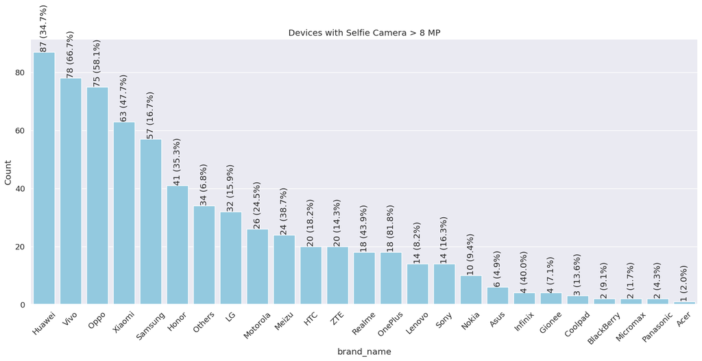

```python
# Create a subset of dataframe to analyze data related to devices offering greater than 8MP selfie cameras
uddf_sc8mp = uddf[uddf['selfie_camera_mp']> 8]

#Use plot_countplot_ind() function to understand brands' offerings of selfie camears over 8MP.
plot_countplot_ind(uddf_sc8mp,'brand_name','Devices with Selfie Camera > 8 MP','valueoverallperc')

#Data labels display the count and the percentage of each brand's own devices featuring selfie cameras over 8MP.
```

```python
#Count of devices without selfie (front) camera.
count_of_devices_wo_selfie_camera = uddf[uddf['selfie_camera_mp']==0].shape[0]
print(f'Number of devices without Selfie Camera: {count_of_devices_wo_selfie_camera}')
```

```
Number of devices without Selfie Camera: 39
```

#### 7. Which attributes are highly correlated with the normalized price of a used device?

**Ans:** The correlation analysis between normalized_used_price and other numerical variables reveals:

- **Strong Positive Correlation with New Device Prices:** normalized_new_price has a correlation coefficient of 0.83, implying that devices with higher new prices tend to retain their value, fetching higher prices even when used.
- **Moderate Positive Influences:** Variables like screen_size, battery, selfie_camera_mp, main_camera_mp, ram, and release_year demonstrate moderate correlations. These factors moderately influence the used device prices, indicating that features such as better cameras, larger screens, and recent release years add value to used devices.
- **Negative Correlation with Usage Duration:** days_used shows a moderate negative correlation, indicating that devices used for longer durations tend to decrease in value, aligning with the general expectation of wear and depreciation over time.

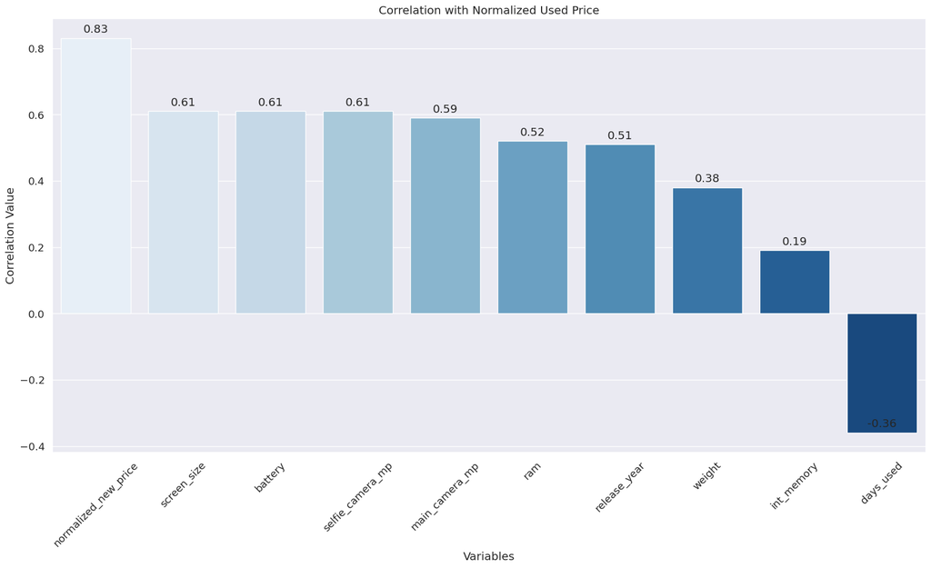

```python
# Calculate the correlation matrix, extract the correlations of 'normalized_used_price' with other numerical variables
correlation_matrix = uddf.corr()['normalized_used_price'].sort_values(ascending=False).drop('normalized_used_price').round(2)

#Use the barplot to visualize the correlation
plot_single_variable_correlation(correlation_matrix)
```

## Data Preprocessing

- Missing value treatment
- Outlier detection and treatment (if needed)
- Feature engineering (if needed)
- Preparing data for modeling
- Any other preprocessing steps (if needed)

```python
#Create a copy of the dataframe to apply transformation.
uddf_transformed = uddf.copy()
uddf_transformed.head()
```

|  | brand_name | os | screen_size | 4g | 5g | main_camera_mp | selfie_camera_mp | int_memory | ram | battery | weight | release_year | days_used | normalized_used_price | normalized_new_price |
| --- | --- | --- | --- | --- | --- | --- | --- | --- | --- | --- | --- | --- | --- | --- | --- |
| 0 | Honor | Android | 14.50 | yes | no | 13.0 | 5.0 | 64.0 | 3.0 | 3020.0 | 146.0 | 2020 | 127 | 4.307572 | 4.715100 |
| 1 | Honor | Android | 17.30 | yes | yes | 13.0 | 16.0 | 128.0 | 8.0 | 4300.0 | 213.0 | 2020 | 325 | 5.162097 | 5.519018 |
| 2 | Honor | Android | 16.69 | yes | yes | 13.0 | 8.0 | 128.0 | 8.0 | 4200.0 | 213.0 | 2020 | 162 | 5.111084 | 5.884631 |
| 3 | Honor | Android | 25.50 | yes | yes | 13.0 | 8.0 | 64.0 | 6.0 | 7250.0 | 480.0 | 2020 | 345 | 5.135387 | 5.630961 |
| 4 | Honor | Android | 15.32 | yes | no | 13.0 | 8.0 | 64.0 | 3.0 | 5000.0 | 185.0 | 2020 | 293 | 4.389995 | 4.947837 |

### Missing Value Treatment

```python
#List all missing (null) values
uddf_transformed.isna().sum().sort_values(ascending=False)
```

```
main_camera_mp           179
weight                     7
battery                    6
int_memory                 4
ram                        4
selfie_camera_mp           2
brand_name                 0
os                         0
screen_size                0
4g                         0
5g                         0
release_year               0
days_used                  0
normalized_used_price      0
normalized_new_price       0
dtype: int64
```

#### Observations:

The analysis of missing values reveals that **main_camera_mp:** 179 (5.18%), **selfie_camera_mp:** 2 (0.06%), **int_memory:** 4 (0.12%), **ram:** 4 (0.12%), **battery:** 6 (0.17%) and **weight:** 7 (0.20%) have missing values but they are no significantly large.

**Recommendation:** Variables do not have normal distribution and have significant outliers, which demands median imputation for missing values. It is highly recommended to employ group-specific median imputation for missing values in the used_device_data.csv dataset. This nuanced approach to imputation will likely yield a dataset that more accurately represents the real-world variations and relationships, leading to more reliable analyses and predictive modeling outcomes.

#### Missing value imputation

```python
from sklearn.impute import SimpleImputer
# Initialize an imputer object with a median filling strategy
imputer = SimpleImputer(strategy='median')

# Identify columns with missing values
columns_with_missing_values = uddf_transformed.columns[uddf_transformed.isnull().any()].tolist()

# For each column with missing values, apply median imputation within each group
for column in columns_with_missing_values:
    # Apply median imputation within each group defined by 'brand_name' and 'os'
    uddf_transformed[column] = uddf_transformed.groupby(['brand_name', 'release_year'])[column].transform(lambda x: x.fillna(x.median()) if not x.median() is np.nan else x)

# Verify if the missing values are filled
uddf_transformed.isnull().sum()
```

```
brand_name                 0
os                         0
screen_size                0
4g                         0
5g                         0
main_camera_mp           179
selfie_camera_mp           2
int_memory                 0
ram                        0
battery                    6
weight                     7
release_year               0
days_used                  0
normalized_used_price      0
normalized_new_price       0
dtype: int64
```

- **int_memory** and **ram** seems to have treated for missing values.
- We need to elminate missing values from main_camera_mp, selfie_camera_mp, battery and weight.
- We will impute the values by grouping the records by brand_name only.

```python
# Identify columns with missing values
columns_with_missing_values2 = uddf_transformed.columns[uddf_transformed.isnull().any()].tolist()

# For each column with missing values, apply median imputation within each group
for column in columns_with_missing_values2:
    # Apply median imputation within each group defined by 'brand_name' and 'os'
    uddf_transformed[column] = uddf_transformed.groupby(['brand_name'])[column].transform(lambda x: x.fillna(x.median()) if not x.median() is np.nan else x)

# Verify if the missing values are filled
uddf_transformed.isnull().sum()
```

```
brand_name                0
os                        0
screen_size               0
4g                        0
5g                        0
main_camera_mp           10
selfie_camera_mp          0
int_memory                0
ram                       0
battery                   0
weight                    0
release_year              0
days_used                 0
normalized_used_price     0
normalized_new_price      0
dtype: int64
```

- We managed to remove missing values from most variables.
- There 10 missing values under main_camera_mp variables, let's review these records.

```python
# Identifying rows where main_camera_mp has missing value
uddf_transformed[uddf_transformed['main_camera_mp'].isnull()]
```

|  | brand_name | os | screen_size | 4g | 5g | main_camera_mp | selfie_camera_mp | int_memory | ram | battery | weight | release_year | days_used | normalized_used_price | normalized_new_price |
| --- | --- | --- | --- | --- | --- | --- | --- | --- | --- | --- | --- | --- | --- | --- | --- |
| 59 | Infinix | Android | 17.32 | yes | no | NaN | 8.0 | 32.0 | 2.0 | 6000.0 | 209.0 | 2020 | 245 | 4.282068 | 4.597642 |
| 60 | Infinix | Android | 15.39 | yes | no | NaN | 8.0 | 64.0 | 4.0 | 5000.0 | 185.0 | 2020 | 173 | 4.363608 | 4.711780 |
| 61 | Infinix | Android | 15.39 | yes | no | NaN | 8.0 | 32.0 | 2.0 | 5000.0 | 185.0 | 2020 | 256 | 4.181439 | 4.505460 |
| 62 | Infinix | Android | 15.39 | yes | no | NaN | 16.0 | 32.0 | 3.0 | 4000.0 | 178.0 | 2019 | 316 | 4.555244 | 4.602166 |
| 63 | Infinix | Android | 15.29 | yes | no | NaN | 16.0 | 32.0 | 2.0 | 4000.0 | 165.0 | 2019 | 468 | 4.416670 | 4.871297 |
| 278 | Infinix | Android | 17.32 | yes | no | NaN | 8.0 | 32.0 | 2.0 | 6000.0 | 209.0 | 2020 | 320 | 4.405133 | 4.605370 |
| 279 | Infinix | Android | 15.39 | yes | no | NaN | 8.0 | 64.0 | 4.0 | 5000.0 | 185.0 | 2020 | 173 | 4.495913 | 4.702115 |
| 280 | Infinix | Android | 15.39 | yes | no | NaN | 8.0 | 32.0 | 2.0 | 5000.0 | 185.0 | 2020 | 329 | 4.370713 | 4.487287 |
| 281 | Infinix | Android | 15.39 | yes | no | NaN | 16.0 | 32.0 | 3.0 | 4000.0 | 178.0 | 2019 | 356 | 4.417997 | 4.605970 |
| 282 | Infinix | Android | 15.29 | yes | no | NaN | 16.0 | 32.0 | 2.0 | 4000.0 | 165.0 | 2019 | 497 | 4.423289 | 4.866072 |

```python
# Impute the missing values of 'main_camera_mp' based on the median of the column.

# Calculate the median value for 'main_camera_mp'
median_value = uddf_transformed['main_camera_mp'].median()

# Fill missing values in 'main_camera_mp' with the median value
uddf_transformed['main_camera_mp'] = uddf_transformed['main_camera_mp'].fillna(median_value)

# Verify if the missing values are filled
uddf_transformed.isnull().sum()
```

```
brand_name               0
os                       0
screen_size              0
4g                       0
5g                       0
main_camera_mp           0
selfie_camera_mp         0
int_memory               0
ram                      0
battery                  0
weight                   0
release_year             0
days_used                0
normalized_used_price    0
normalized_new_price     0
dtype: int64
```

- All missing values have been treated.

#### Outlier Treatments

Treating outliers is essential in preparing the data for Linear Regression, as extreme values can disproportionately affect the model's performance. Following function is written to visualize the outliers;

1. **plot_numeric_boxplot(*dataframe*):** This function will plot boxplots for all numeric variables to visualize the data and to understand the distribution and identify potential outliers.

```python
def plot_numeric_boxplots(dataframe):
    """
    Plot boxplots for all numeric variables in the dataframe, displaying 4 boxplots per row.

    Args:
    dataframe (pd.DataFrame): The dataframe containing the data.
    """
    num_columns = dataframe.select_dtypes(include=['float64', 'int64']).columns
    num_of_columns = len(num_columns)
    num_of_rows = (num_of_columns - 1) // 4 + 1  # Calculate the number of rows needed

    # Set up the matplotlib figure
    fig, axes = plt.subplots(num_of_rows, 4, figsize=(20, 5 * num_of_rows))

    for i, column in enumerate(num_columns):
        # Determine the position of the current plot
        row = i // 4
        col = i % 4

        if num_of_rows == 1:  # If there's only one row, axes is a 1D array
            ax = axes[col]
        else:  # Otherwise, axes is a 2D array
            ax = axes[row, col]

        sns.boxplot(x=dataframe[column], ax=ax)
        ax.set_title(f'Boxplot of {column}', fontsize=14)

        # If there are no more columns to plot, hide the remaining axes
        if i == num_of_columns - 1:
            for j in range(i + 1, num_of_rows * 4):
                axes.flat[j].set_visible(False)

    # Adjust layout
    plt.tight_layout()
    plt.show()

def remove_outliers(dataframe):
    """
    Remove outliers for all numeric variables in the dataframe based on the IQR method, except for 'ram'.

    Args:
    dataframe (pd.DataFrame): The dataframe containing the data.

    Returns:
    pd.DataFrame: The dataframe with outliers removed, except for 'ram'.
    """
    Q1 = dataframe.quantile(0.25)
    Q3 = dataframe.quantile(0.75)
    IQR = Q3 - Q1

    # Define numeric columns, excluding 'ram'
    numeric_columns = dataframe.select_dtypes(include=['float64', 'int64']).columns
    numeric_columns = numeric_columns.drop('ram') if 'ram' in numeric_columns else numeric_columns

    # Cap the outliers
    for column in numeric_columns:
        lower_bound = Q1[column] - 1.5 * IQR[column]
        upper_bound = Q3[column] + 1.5 * IQR[column]
        dataframe[column] = dataframe[column].clip(lower=lower_bound, upper=upper_bound)

    return dataframe
```

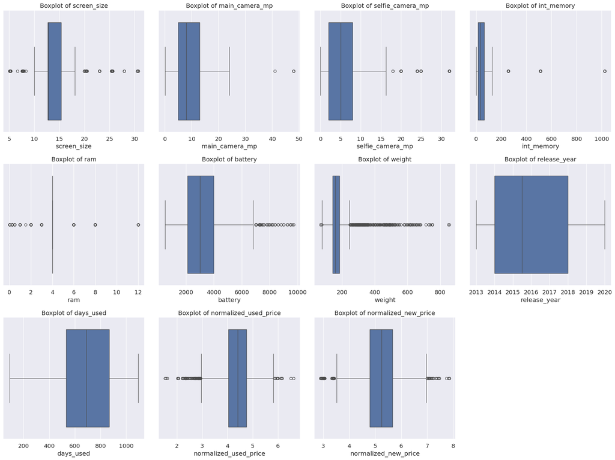

```python
# Visualize the distribution and identify potential outliers.
plot_numeric_boxplots(uddf_transformed)
```

#### Outlier Treatment:

- The boxplot shows that **all predictors except release_year and days_used** have outliers.
- However, since most values are proper values, we **will not be treating** the outliers.

### EDA after Data Preprocessing

```python
#check the statistical summary once again
uddf_transformed.describe(include="all").T
```

|  | count | unique | top | freq | mean | std | min | 25% | 50% | 75% | max |
| --- | --- | --- | --- | --- | --- | --- | --- | --- | --- | --- | --- |
| brand_name | 3454 | 34 | Others | 502 | NaN | NaN | NaN | NaN | NaN | NaN | NaN |
| os | 3454 | 4 | Android | 3214 | NaN | NaN | NaN | NaN | NaN | NaN | NaN |
| screen_size | 3454.0 | NaN | NaN | NaN | 13.713115 | 3.80528 | 5.08 | 12.7 | 12.83 | 15.34 | 30.71 |
| 4g | 3454 | 2 | yes | 2335 | NaN | NaN | NaN | NaN | NaN | NaN | NaN |
| 5g | 3454 | 2 | no | 3302 | NaN | NaN | NaN | NaN | NaN | NaN | NaN |
| main_camera_mp | 3454.0 | NaN | NaN | NaN | 9.617597 | 4.749438 | 0.08 | 5.0 | 8.0 | 13.0 | 48.0 |
| selfie_camera_mp | 3454.0 | NaN | NaN | NaN | 6.555067 | 6.96844 | 0.0 | 2.0 | 5.0 | 8.0 | 32.0 |
| int_memory | 3454.0 | NaN | NaN | NaN | 54.528474 | 84.934991 | 0.01 | 16.0 | 32.0 | 64.0 | 1024.0 |
| ram | 3454.0 | NaN | NaN | NaN | 4.03262 | 1.368598 | 0.02 | 4.0 | 4.0 | 4.0 | 12.0 |
| battery | 3454.0 | NaN | NaN | NaN | 3132.577446 | 1298.884193 | 500.0 | 2100.0 | 3000.0 | 4000.0 | 9720.0 |
| weight | 3454.0 | NaN | NaN | NaN | 182.636856 | 88.360445 | 69.0 | 142.0 | 160.0 | 185.0 | 855.0 |
| release_year | 3454.0 | NaN | NaN | NaN | 2015.965258 | 2.298455 | 2013.0 | 2014.0 | 2015.5 | 2018.0 | 2020.0 |
| days_used | 3454.0 | NaN | NaN | NaN | 674.869716 | 248.580166 | 91.0 | 533.5 | 690.5 | 868.75 | 1094.0 |
| normalized_used_price | 3454.0 | NaN | NaN | NaN | 4.364712 | 0.588914 | 1.536867 | 4.033931 | 4.405133 | 4.7557 | 6.619433 |
| normalized_new_price | 3454.0 | NaN | NaN | NaN | 5.233107 | 0.683637 | 2.901422 | 4.790342 | 5.245892 | 5.673718 | 7.847841 |

### Feature Engineering

#### Dropping column **brand_name**

**Rationale behind dropping brand_name:**

**High Dimensionality:** One-hot encoding the brand_name with 34 unique categories would significantly increase the dataset's dimensionality, leading to potential overfitting.

**Redundancy with os:** The os column, which has fewer categories, may capture relevant brand-related information, making brand_name potentially redundant.

**Model Simplification:** Removing brand_name simplifies the model, aiding interpretability and reducing the risk of multicollinearity, especially when combined with other categorical variables like os.

```python
# Drop brand_name from the dataframe and create final dataframe
uddf_final = uddf_transformed.drop('brand_name', axis=1)
uddf_final.info()
```

```
<class 'pandas.core.frame.DataFrame'>
RangeIndex: 3454 entries, 0 to 3453
Data columns (total 14 columns):
 #   Column                 Non-Null Count  Dtype
---  ------                 --------------  -----
 0   os                     3454 non-null   object
 1   screen_size            3454 non-null   float64
 2   4g                     3454 non-null   object
 3   5g                     3454 non-null   object
 4   main_camera_mp         3454 non-null   float64
 5   selfie_camera_mp       3454 non-null   float64
 6   int_memory             3454 non-null   float64
 7   ram                    3454 non-null   float64
 8   battery                3454 non-null   float64
 9   weight                 3454 non-null   float64
 10  release_year           3454 non-null   int64
 11  days_used              3454 non-null   int64
 12  normalized_used_price  3454 non-null   float64
 13  normalized_new_price   3454 non-null   float64
dtypes: float64(9), int64(2), object(3)
memory usage: 377.9+ KB
```

#### Creating Age of the device

Device age provides a more direct, uniform measure of a device's lifecycle and depreciation than the release year, making it more relevant for predictive modeling.

```python
#create new column device_age and drop release_year, assuming the maximum value in release_year is for current year.
max_year = uddf_final['release_year'].max()
uddf_final['device_age'] = max_year - uddf_final['release_year']

#drop release_year column from dataframe
uddf_final.drop('release_year', axis=1, inplace=True)

# Display the first few rows of the updated dataframe to confirm the changes
uddf_final.head()
```

|  | os | screen_size | 4g | 5g | main_camera_mp | selfie_camera_mp | int_memory | ram | battery | weight | days_used | normalized_used_price | normalized_new_price | device_age |
| --- | --- | --- | --- | --- | --- | --- | --- | --- | --- | --- | --- | --- | --- | --- |
| 0 | Android | 14.50 | yes | no | 13.0 | 5.0 | 64.0 | 3.0 | 3020.0 | 146.0 | 127 | 4.307572 | 4.715100 | 0 |
| 1 | Android | 17.30 | yes | yes | 13.0 | 16.0 | 128.0 | 8.0 | 4300.0 | 213.0 | 325 | 5.162097 | 5.519018 | 0 |
| 2 | Android | 16.69 | yes | yes | 13.0 | 8.0 | 128.0 | 8.0 | 4200.0 | 213.0 | 162 | 5.111084 | 5.884631 | 0 |
| 3 | Android | 25.50 | yes | yes | 13.0 | 8.0 | 64.0 | 6.0 | 7250.0 | 480.0 | 345 | 5.135387 | 5.630961 | 0 |
| 4 | Android | 15.32 | yes | no | 13.0 | 8.0 | 64.0 | 3.0 | 5000.0 | 185.0 | 293 | 4.389995 | 4.947837 | 0 |

#### Transform 4g and 5g categorical columns

Transforming 4G and 5G columns into binary values standardizes their format for models to efficiently process and analyze the presence or absence of these features.

```python
# Replace 'yes' with 1 and 'no' with 0 in '4g' and '5g' columns and change data type to int64
uddf_final['4g'] = uddf_final['4g'].replace({'yes': 1, 'no': 0}).astype('int64')
uddf_final['5g'] = uddf_final['5g'].replace({'yes': 1, 'no': 0}).astype('int64')

# Display the first few rows of the updated dataframe to confirm the changes
uddf_final.head()
```

|  | os | screen_size | 4g | 5g | main_camera_mp | selfie_camera_mp | int_memory | ram | battery | weight | days_used | normalized_used_price | normalized_new_price | device_age |
| --- | --- | --- | --- | --- | --- | --- | --- | --- | --- | --- | --- | --- | --- | --- |
| 0 | Android | 14.50 | 1 | 0 | 13.0 | 5.0 | 64.0 | 3.0 | 3020.0 | 146.0 | 127 | 4.307572 | 4.715100 | 0 |
| 1 | Android | 17.30 | 1 | 1 | 13.0 | 16.0 | 128.0 | 8.0 | 4300.0 | 213.0 | 325 | 5.162097 | 5.519018 | 0 |
| 2 | Android | 16.69 | 1 | 1 | 13.0 | 8.0 | 128.0 | 8.0 | 4200.0 | 213.0 | 162 | 5.111084 | 5.884631 | 0 |
| 3 | Android | 25.50 | 1 | 1 | 13.0 | 8.0 | 64.0 | 6.0 | 7250.0 | 480.0 | 345 | 5.135387 | 5.630961 | 0 |
| 4 | Android | 15.32 | 1 | 0 | 13.0 | 8.0 | 64.0 | 3.0 | 5000.0 | 185.0 | 293 | 4.389995 | 4.947837 | 0 |

#### One-hot encoding, creating dummy variables for categorical variables.

- One-hot encoding transforms categorical variables into a format that can be provided to ML algorithms to improve prediction accuracy without introducing feature collinearity.
- We will use this feature to convert categorical variable **os**.

```python
# One-hot encode 'os' columns with drop_first=True
uddf_final = pd.get_dummies(uddf_final, columns=['os'], drop_first=True)

# Display feature data types to ensure there are no categorical variables.
uddf_final.dtypes
```

```
screen_size              float64
4g                         int64
5g                         int64
main_camera_mp           float64
selfie_camera_mp         float64
int_memory               float64
ram                      float64
battery                  float64
weight                   float64
days_used                  int64
normalized_used_price    float64
normalized_new_price     float64
device_age                 int64
os_Others                  uint8
os_Windows                 uint8
os_iOS                     uint8
dtype: object
```

```python
#Display first few rows of the transformed dataframe.
uddf_final.head()
```

|  | screen_size | 4g | 5g | main_camera_mp | selfie_camera_mp | int_memory | ram | battery | weight | days_used | normalized_used_price | normalized_new_price | device_age | os_Others | os_Windows | os_iOS |
| --- | --- | --- | --- | --- | --- | --- | --- | --- | --- | --- | --- | --- | --- | --- | --- | --- |
| 0 | 14.50 | 1 | 0 | 13.0 | 5.0 | 64.0 | 3.0 | 3020.0 | 146.0 | 127 | 4.307572 | 4.715100 | 0 | 0 | 0 | 0 |
| 1 | 17.30 | 1 | 1 | 13.0 | 16.0 | 128.0 | 8.0 | 4300.0 | 213.0 | 325 | 5.162097 | 5.519018 | 0 | 0 | 0 | 0 |
| 2 | 16.69 | 1 | 1 | 13.0 | 8.0 | 128.0 | 8.0 | 4200.0 | 213.0 | 162 | 5.111084 | 5.884631 | 0 | 0 | 0 | 0 |
| 3 | 25.50 | 1 | 1 | 13.0 | 8.0 | 64.0 | 6.0 | 7250.0 | 480.0 | 345 | 5.135387 | 5.630961 | 0 | 0 | 0 | 0 |
| 4 | 15.32 | 1 | 0 | 13.0 | 8.0 | 64.0 | 3.0 | 5000.0 | 185.0 | 293 | 4.389995 | 4.947837 | 0 | 0 | 0 | 0 |

## Model Building - Linear Regression

### Separating the Target Variable and Features

```python
# Split data
X = uddf_final.drop('normalized_used_price', axis=1)  # Features
y = uddf_final['normalized_used_price']  # Target Variable

# Add constant to feature set
X = sm.add_constant(X)
```

```python
# Display top rows of split feature set.
X.head()
```

|  | const | screen_size | 4g | 5g | main_camera_mp | selfie_camera_mp | int_memory | ram | battery | weight | days_used | normalized_new_price | device_age | os_Others | os_Windows | os_iOS |
| --- | --- | --- | --- | --- | --- | --- | --- | --- | --- | --- | --- | --- | --- | --- | --- | --- |
| 0 | 1.0 | 14.50 | 1 | 0 | 13.0 | 5.0 | 64.0 | 3.0 | 3020.0 | 146.0 | 127 | 4.715100 | 0 | 0 | 0 | 0 |
| 1 | 1.0 | 17.30 | 1 | 1 | 13.0 | 16.0 | 128.0 | 8.0 | 4300.0 | 213.0 | 325 | 5.519018 | 0 | 0 | 0 | 0 |
| 2 | 1.0 | 16.69 | 1 | 1 | 13.0 | 8.0 | 128.0 | 8.0 | 4200.0 | 213.0 | 162 | 5.884631 | 0 | 0 | 0 | 0 |
| 3 | 1.0 | 25.50 | 1 | 1 | 13.0 | 8.0 | 64.0 | 6.0 | 7250.0 | 480.0 | 345 | 5.630961 | 0 | 0 | 0 | 0 |
| 4 | 1.0 | 15.32 | 1 | 0 | 13.0 | 8.0 | 64.0 | 3.0 | 5000.0 | 185.0 | 293 | 4.947837 | 0 | 0 | 0 | 0 |

```python
# Display top rows of split target set.
y.head()
```

```
0    4.307572
1    5.162097
2    5.111084
3    5.135387
4    4.389995
Name: normalized_used_price, dtype: float64
```

### Splitting the Data into Training and Testing Sets

```python
# Use train_test_split() to create train and test sets for features and target variable. The Train, Test ratio will be 70:30.
X_train, X_test, y_train, y_test = train_test_split(X, y, test_size=0.3, random_state=1)

# Display the training and test shape to confirm the size
print(f'Training Set: {X_train.shape}, ({100 * X_train.shape[0]/X.shape[0]:.0f}%)')
print(f'Test Set: {X_test.shape}, ({100 * X_test.shape[0]/X.shape[0]:.0f}%)')
```

```
Training Set: (2417, 16), (70%)
Test Set: (1037, 16), (30%)
```

### Model building using statsmodels OLS and print the model summary

```python
#Build OLS model
olsmodel = sm.OLS(y_train, X_train).fit()
print(olsmodel.summary())
```

```
                              OLS Regression Results
=================================================================================
Dep. Variable:     normalized_used_price   R-squared:                       0.842
Model:                               OLS   Adj. R-squared:                  0.841
Method:                    Least Squares   F-statistic:                     850.5
Date:                   Thu, 01 Feb 2024   Prob (F-statistic):               0.00
Time:                           23:51:36   Log-Likelihood:                 98.614
No. Observations:                   2417   AIC:                            -165.2
Df Residuals:                       2401   BIC:                            -72.58
Df Model:                             15
Covariance Type:               nonrobust
========================================================================================
                           coef    std err          t      P>|t|      [0.025      0.975]
----------------------------------------------------------------------------------------
const                    1.3448      0.052     25.775      0.000       1.242       1.447
screen_size              0.0254      0.003      7.636      0.000       0.019       0.032
4g                       0.0477      0.015      3.129      0.002       0.018       0.078
5g                      -0.0504      0.031     -1.635      0.102      -0.111       0.010
main_camera_mp           0.0209      0.001     14.822      0.000       0.018       0.024
selfie_camera_mp         0.0139      0.001     12.867      0.000       0.012       0.016
int_memory            9.782e-05   6.69e-05      1.461      0.144   -3.34e-05       0.000
ram                      0.0205      0.005      4.110      0.000       0.011       0.030
battery              -1.294e-05   7.09e-06     -1.826      0.068   -2.68e-05    9.57e-07
weight                   0.0009      0.000      7.175      0.000       0.001       0.001
days_used             4.651e-05   3.05e-05      1.526      0.127   -1.33e-05       0.000
normalized_new_price     0.4215      0.011     37.277      0.000       0.399       0.444
device_age              -0.0255      0.004     -5.730      0.000      -0.034      -0.017
os_Others               -0.0486      0.029     -1.651      0.099      -0.106       0.009
os_Windows               0.0266      0.036      0.732      0.464      -0.045       0.098
os_iOS                  -0.0619      0.045     -1.385      0.166      -0.150       0.026
==============================================================================
Omnibus:                      236.533   Durbin-Watson:                   1.909
Prob(Omnibus):                  0.000   Jarque-Bera (JB):              461.165
Skew:                          -0.639   Prob(JB):                    7.23e-101
Kurtosis:                       4.716   Cond. No.                     4.07e+04
==============================================================================

Notes:
[1] Standard Errors assume that the covariance matrix of the errors is correctly specified.
[2] The condition number is large, 4.07e+04. This might indicate that there are
strong multicollinearity or other numerical problems.
```

#### Observations:

**The OLS Regression Results reveal:**

1. **Model Fit:** The **model explains 84.2%** of the variance in **normalized_used_price** (R-squared: 0.842), indicating a **good fit**.
2. **Significant Positive Predictor(s):** **normalized_new_price** shows the strongest influence (**0.4215**) over **normalized_used_price**.
3. **Negative Predictor(s):** Predictor **5g** shows moderately negative influence (**-0.0504**) on **normalized_used_price**.
4. **High p-values:** 5g, int_memory, battery, days_used, and os variables show high p-value.
5. **Baseline Value (Y-intercept):** The **const** coefficient (1.3448) suggests that, in the absence of all other predictors, the **normalized_used_price** is expected to be approximately 1.3448.

## Model Performance Check

Evaluating model performance is essential to confirm its accuracy, reliability, and generalization to new data. It identifies strengths and areas for improvement, ensuring the model's real-world applicability.

**Evaluating Model Performance:** A comprehensive set of metrics including RMSE, MAE, R-squared, Adjusted R-squared, and MAPE will be used to assess the model's predictive accuracy and explanatory power. These metrics, presented in a unified dataframe, offer a detailed evaluation, guiding model refinement and optimization.

### Functions to check the performance of the model using different metrics.

```python
def adj_r2_score(predictors, targets, predictions):
    """
    Calculate adjusted R-squared score.

    Args:
    predictors: numpy array or pandas dataframe containing predictor variables
    targets: numpy array or pandas series containing actual target values
    predictions: numpy array or pandas series containing predicted values

    Returns:
    float: adjusted R-squared score
    """
    r2 = r2_score(targets, predictions)
    n = predictors.shape[0]  # number of observations
    k = predictors.shape[1]  # number of predictor variables
    # Adjusted R-squared calculation
    return 1 - ((1 - r2) * (n - 1) / (n - k - 1))


def mape_score(targets, predictions):
    """
    Calculate Mean Absolute Percentage Error (MAPE).

    Args:
    targets: numpy array or pandas series containing actual target values
    predictions: numpy array or pandas series containing predicted values

    Returns:
    float: MAPE score
    """
    # MAPE calculation
    return np.mean(np.abs(targets - predictions) / targets) * 100


def model_performance_regression(model, predictors, target):
    """
    Compute performance metrics for a regression model.

    Args:
    model: trained regression model
    predictors: numpy array or pandas dataframe containing predictor variables
    target: numpy array or pandas series containing actual target values

    Returns:
    pd.DataFrame: dataframe containing performance metrics
    """
    # Making predictions using the independent variables
    pred = model.predict(predictors)

    # Calculating various performance metrics
    r2 = r2_score(target, pred)  # Compute R-squared
    adjr2 = adj_r2_score(predictors, target, pred)  # Compute Adjusted R-squared
    rmse = np.sqrt(mean_squared_error(target, pred))  # Compute Root Mean Squared Error (RMSE)
    mae = mean_absolute_error(target, pred)  # Compute Mean Absolute Error (MAE)
    mape = mape_score(target, pred)  # Compute Mean Absolute Percentage Error (MAPE)

    # Creating a dataframe to display the metrics
    df_perf = pd.DataFrame(
        {
            "RMSE": rmse,
            "MAE": mae,
            "R-squared": r2,
            "Adj. R-squared": adjr2,
            "MAPE": mape,
        },
        index=[0],
    )

    return df_perf
```

### Performance Check for Train Dataset

```python
# checking model performance on train set (seen 70% data)
print("Training Dataset Performance:\n")
olsmodel_train_perf = model_performance_regression(olsmodel, X_train, y_train)
olsmodel_train_perf
```

```
Training Dataset Performance:
```

|  | RMSE | MAE | R-squared | Adj. R-squared | MAPE |
| --- | --- | --- | --- | --- | --- |
| 0 | 0.232297 | 0.18226 | 0.841612 | 0.840556 | 4.377609 |

### Performance Check for Test Dataset

```python
# checking model performance on test set (seen 30% data)
print("Test Dataset Performance:\n")
olsmodel_test_perf = model_performance_regression(olsmodel, X_test, y_test)
olsmodel_test_perf
```

```
Test Dataset Performance:
```

|  | RMSE | MAE | R-squared | Adj. R-squared | MAPE |
| --- | --- | --- | --- | --- | --- |
| 0 | 0.236589 | 0.183001 | 0.844808 | 0.842374 | 4.467715 |

### Observations:

**Stable Model Fit:** The model demonstrates stability with close R-squared values in training (0.841612) and test sets (0.844808), suggesting effective generalization without significant overfitting.

**High Prediction Accuracy:** Low and comparable RMSE (training: 0.232297, test: 0.236589) and MAE (training: 0.18226, test: 0.183001) across both sets indicate high prediction accuracy and a well-balanced model.

**Error Consistency:** The increase in MAPE from the training set (4.377609) to the test set (4.46715) is minimal, indicating consistent error margins and reliable prediction capabilities across unseen data.

**Adjusted R-squared Validation:** The slight increase in Adjusted R-squared from the training set (0.840556) to the test set (0.842374) confirms that the model's explanatory power is effectively maintained without adding unnecessary complexity.

## Checking Linear Regression Assumptions

- In order to make statistical inferences from a linear regression model, it is important to ensure that the assumptions of linear regression are satisfied.
1. Test for Multicollinearity
2. Treating High P-value
3. Test for Linearity and Independence
4. Test for Normality
5. Test for Homoscedasticity

### 1. Test for Multicollinearity

- Multicollinearity testing ensures predictor variables in the regression model are independent.
- The Variance Inflation Factor (VIF) will be used to identify and quantify multicollinearity among predictors.

```python
from statsmodels.stats.outliers_influence import variance_inflation_factor

def checking_vif(predictors):
    """
    Calculates the Variance Inflation Factor (VIF) for each predictor variable to identify multicollinearity issues in the regression model.
    Args: predictors (DataFrame): DataFrame containing the predictor variables.
    Returns: DataFrame: DataFrame with features and their corresponding VIF.
    """
    # Initialize a DataFrame to store VIF values
    vif = pd.DataFrame()

    # Add the feature names to the DataFrame
    vif["feature"] = predictors.columns

    # Calculate VIF for each feature and store it in the DataFrame
    vif["VIF"] = [
        variance_inflation_factor(predictors.values, i)
        for i in range(len(predictors.columns))
    ]

    # Return the DataFrame containing features and their VIF values
    return vif
```

```python
# Variance Inflation Factor (VIF) check and display results
checking_vif(X_train)
```

|  | feature | VIF |
| --- | --- | --- |
| 0 | const | 121.122079 |
| 1 | screen_size | 7.245006 |
| 2 | 4g | 2.260317 |
| 3 | 5g | 1.722728 |
| 4 | main_camera_mp | 1.996930 |
| 5 | selfie_camera_mp | 2.575590 |
| 6 | int_memory | 1.247856 |
| 7 | ram | 2.117161 |
| 8 | battery | 3.848932 |
| 9 | weight | 6.127196 |
| 10 | days_used | 2.578113 |
| 11 | normalized_new_price | 2.632565 |
| 12 | device_age | 4.627080 |
| 13 | os_Others | 1.484575 |
| 14 | os_Windows | 1.023364 |
| 15 | os_iOS | 1.089167 |

#### Observations and Suggested Actions for treating Multicollinearity:

Observations reveal that **screen_size** (7.245006) and **weight** (6.127196) exhibit high VIF values (> 5), signaling strong multicollinearity.

**Action Plan:**

1. Systematically remove numerical columns where VIF exceeds 5 to mitigate multicollinearity.
2. Test the feature set after removing affected columns.

#### Multicollinearity Mitigation Steps

**Affected columns:** **screen_size** and **weight**.

Define function to complete the following tasks:

1. **Iterative Removal:** Sequentially drop columns with VIF > 5, one at a time.
2. **Model Evaluation:** Post-removal, assess the model using Adjusted R-squared and RMSE.
3. **Minimal Impact Selection:** Prefer dropping the column with the least effect on Adjusted R-squared.
4. **VIF Recalculation:** Reevaluate VIF scores after each column removal.
5. **Completion Check:** Continue the process until all VIF scores are below 5.

```python
# Function to drop affected column and test the model performance after dropping.

def treating_multicollinearity(predictors, target, high_vif_columns):
    """
    Evaluate the impact of removing high VIF columns on model performance (Adj. R-squared & RMSE).

    Args:
    predictors (pd.DataFrame): DataFrame containing predictor variables.
    target (pd.Series): Series containing target variable.
    high_vif_columns (list): List of column names with high VIF.

    Returns:
    pd.DataFrame: DataFrame with performance metrics after dropping each high VIF column.
    """
    adj_r2 = []  # Store adjusted R-squared values
    rmse = []    # Store RMSE values

    # Iterate through high VIF columns and assess model performance after dropping each
    for col in high_vif_columns:
        # Define the predictor set excluding the current high VIF column
        train = predictors.drop(columns=[col])

        # Fit OLS model
        ols_model = sm.OLS(target, train).fit()

        # Append performance metrics
        adj_r2.append(ols_model.rsquared_adj)
        rmse.append(np.sqrt(ols_model.mse_resid))

    # Compile results into a DataFrame
    result_df = pd.DataFrame({
        "Dropped Column": high_vif_columns,
        "Adj. R-squared": adj_r2,
        "RMSE": rmse,
    }).sort_values(by="Adj. R-squared", ascending=False).reset_index(drop=True)

    return result_df
```

```python
# Set columns to check
cols_to_check = ['screen_size','weight']

# Use treating_multicollinearity() function to get test results
t_result = treating_multicollinearity(X_train, y_train, cols_to_check)

# Display model performance before and after dropping affected predictors
t_result
```

|  | Dropped Column | Adj. R-squared | RMSE |
| --- | --- | --- | --- |
| 0 | weight | 0.837274 | 0.235506 |
| 1 | screen_size | 0.836820 | 0.235834 |

#### After treating multicollinearity for each predictors.

1. The test suggests that after dropping variables with high VIF, greater than 5, Adj. R-squared value has moderatly reduced. Results show that dropping **screen_size** results in greater reduction in **Adj. R-squared**.
2. This advises us to drop **weight** column and retain the **screen_size** column.

```python
# Drop 'weight' columns and create new train and test sets

col_to_drop = "weight"
X_train2 = X_train.loc[:, ~X_train.columns.str.startswith(col_to_drop)]
X_test2 = X_test.loc[:, ~X_test.columns.str.startswith(col_to_drop)]

# Check for multicollinearity (VIF) after dropping device_age
checking_vif(X_train2)
```

|  | feature | VIF |
| --- | --- | --- |
| 0 | const | 105.577194 |
| 1 | screen_size | 3.402137 |
| 2 | 4g | 2.239495 |
| 3 | 5g | 1.721245 |
| 4 | main_camera_mp | 1.903762 |
| 5 | selfie_camera_mp | 2.541463 |
| 6 | int_memory | 1.247526 |
| 7 | ram | 2.113643 |
| 8 | battery | 3.469627 |
| 9 | days_used | 2.564951 |
| 10 | normalized_new_price | 2.626262 |
| 11 | device_age | 4.466062 |
| 12 | os_Others | 1.368072 |
| 13 | os_Windows | 1.022647 |
| 14 | os_iOS | 1.080979 |

#### Observations after removing affected columns:

After removing the **weight** column and conducting a VIF check, the following observations were made:

- The removal of **weight** effectively reduced the VIF of **screen_size** to **below 5** (3.402137), addressing the multicollinearity concern for this variable.
- The VIF values for all remaining predictors are now below 5, indicating that the issue of multicollinearity has been successfully mitigated.
- With multicollinearity no longer a concern, we will recreate the model and view the summary.

```python
# Model after No Multicollinearity Check.
olsmodel2 = sm.OLS(y_train, X_train2).fit()
print(olsmodel2.summary())
```

```
                              OLS Regression Results
=================================================================================
Dep. Variable:     normalized_used_price   R-squared:                       0.838
Model:                               OLS   Adj. R-squared:                  0.837
Method:                    Least Squares   F-statistic:                     888.9
Date:                   Thu, 01 Feb 2024   Prob (F-statistic):               0.00
Time:                           23:51:36   Log-Likelihood:                 72.978
No. Observations:                   2417   AIC:                            -116.0
Df Residuals:                       2402   BIC:                            -29.10
Df Model:                             14
Covariance Type:               nonrobust
========================================================================================
                           coef    std err          t      P>|t|      [0.025      0.975]
----------------------------------------------------------------------------------------
const                    1.2107      0.049     24.597      0.000       1.114       1.307
screen_size              0.0427      0.002     18.574      0.000       0.038       0.047
4g                       0.0372      0.015      2.427      0.015       0.007       0.067
5g                      -0.0439      0.031     -1.410      0.159      -0.105       0.017
main_camera_mp           0.0187      0.001     13.453      0.000       0.016       0.021
selfie_camera_mp         0.0130      0.001     11.996      0.000       0.011       0.015
int_memory            9.002e-05   6.76e-05      1.331      0.183   -4.26e-05       0.000
ram                      0.0190      0.005      3.781      0.000       0.009       0.029
battery               3.022e-06    6.8e-06      0.444      0.657   -1.03e-05    1.64e-05
days_used             6.214e-05   3.07e-05      2.022      0.043    1.89e-06       0.000
normalized_new_price     0.4255      0.011     37.284      0.000       0.403       0.448
device_age              -0.0195      0.004     -4.424      0.000      -0.028      -0.011
os_Others                0.0106      0.029      0.370      0.712      -0.045       0.067
os_Windows               0.0335      0.037      0.913      0.361      -0.038       0.105
os_iOS                  -0.0341      0.045     -0.758      0.449      -0.122       0.054
==============================================================================
Omnibus:                      222.355   Durbin-Watson:                   1.913
Prob(Omnibus):                  0.000   Jarque-Bera (JB):              416.130
Skew:                          -0.620   Prob(JB):                     4.35e-91
Kurtosis:                       4.611   Cond. No.                     3.86e+04
==============================================================================

Notes:
[1] Standard Errors assume that the covariance matrix of the errors is correctly specified.
[2] The condition number is large, 3.86e+04. This might indicate that there are
strong multicollinearity or other numerical problems.
```

#### Observations on revised model:

- The moderate reduction in the **Adjusted R-squared** value post-removal indicates that the dropped column had minimal influence on the model's overall explanatory power.
- With multicollinearity resolved, we can now confidently assess the significance of predictor variables by examining their p-values.

### 2. Treating High P-value

In the regression model:

**Null Hypothesis ($H_0$):** The predictor has no impact on normalized_used_price (coefficient = 0).

**Alternative Hypothesis ($H_1$):** The predictor significantly affects normalized_used_price (coefficient ≠ 0).

A p-value < 0.05 rejects H0, indicating a significant relationship. A higher p-value suggests no significant impact.

In this section, we will identify all non-significant predectors and remove one at a time to understand its impact of other predictors.

**We'll streamline the process as follows:**

1. Build a model, identify the variable with the highest p-value, and remove it.
2. Construct a new model without the removed feature and repeat step 1. Continue until all variables have p-values < 0.05.

**Note:** While this can be done manually, using a loop enhances efficiency and reduces tedium.

```python
# Copy the initial list of predictor columns
predictors = X_train2.copy()
cols = predictors.columns.tolist()

# Initialize the maximum p-value
max_p_value = 1

while len(cols) > 0:
    # Define the training set with the current set of predictors
    X_train_aux = predictors[cols]

    # Fit the OLS model with the current predictors
    model = sm.OLS(y_train, X_train_aux).fit()

    # Retrieve the p-values of the model's predictors
    p_values = model.pvalues
    # Get the maximum p-value among the predictors
    max_p_value = max(p_values)
    # Identify the predictor with the highest p-value
    feature_with_p_max = p_values.idxmax()

    # If the highest p-value is greater than the threshold (0.05), remove the corresponding predictor
    if max_p_value > 0.05:
        cols.remove(feature_with_p_max)
    else:
        # If all p-values are below the threshold, stop the loop
        break

# The final list of predictors after removing those with high p-values
selected_features = cols
print(selected_features)
```

```
['const', 'screen_size', '4g', 'main_camera_mp', 'selfie_camera_mp', 'ram', 'days_used', 'normalized_new_price', 'device_age']
```

```python
# Rebuild model after removing features with high p-values
X_train3 = X_train2[selected_features]
X_test3 = X_test2[selected_features]

# Build model
olsmodel3 = sm.OLS(y_train, X_train3).fit()
print(olsmodel3.summary())
```

```
                              OLS Regression Results
=================================================================================
Dep. Variable:     normalized_used_price   R-squared:                       0.838
Model:                               OLS   Adj. R-squared:                  0.837
Method:                    Least Squares   F-statistic:                     1556.
Date:                   Thu, 01 Feb 2024   Prob (F-statistic):               0.00
Time:                           23:51:36   Log-Likelihood:                 70.534
No. Observations:                   2417   AIC:                            -123.1
Df Residuals:                       2408   BIC:                            -70.96
Df Model:                              8
Covariance Type:               nonrobust
========================================================================================
                           coef    std err          t      P>|t|      [0.025      0.975]
----------------------------------------------------------------------------------------
const                    1.2258      0.045     27.486      0.000       1.138       1.313
screen_size              0.0433      0.001     28.862      0.000       0.040       0.046
4g                       0.0365      0.015      2.421      0.016       0.007       0.066
main_camera_mp           0.0188      0.001     14.000      0.000       0.016       0.021
selfie_camera_mp         0.0133      0.001     12.514      0.000       0.011       0.015
ram                      0.0156      0.004      3.618      0.000       0.007       0.024
days_used             6.346e-05   3.05e-05      2.084      0.037    3.75e-06       0.000
normalized_new_price     0.4255      0.011     39.450      0.000       0.404       0.447
device_age              -0.0193      0.004     -4.486      0.000      -0.028      -0.011
==============================================================================
Omnibus:                      222.889   Durbin-Watson:                   1.914
Prob(Omnibus):                  0.000   Jarque-Bera (JB):              426.179
Skew:                          -0.614   Prob(JB):                     2.86e-93
Kurtosis:                       4.650   Cond. No.                     6.79e+03
==============================================================================

Notes:
[1] Standard Errors assume that the covariance matrix of the errors is correctly specified.
[2] The condition number is large, 6.79e+03. This might indicate that there are
strong multicollinearity or other numerical problems.
```

```python
# checking model performance on train set (seen 70% data)
print("Training Performance:\n")
olsmodel3_train_perf = model_performance_regression(olsmodel3, X_train3, y_train)
olsmodel3_train_perf
```

```
Training Performance:
```

|  | RMSE | MAE | R-squared | Adj. R-squared | MAPE |
| --- | --- | --- | --- | --- | --- |
| 0 | 0.235011 | 0.184164 | 0.837889 | 0.837283 | 4.417875 |

```python
# checking model performance on test set (seen 30% data)
print("Test Performance:\n")
olsmodel3_test_perf = model_performance_regression(olsmodel3, X_test3, y_test)
olsmodel3_test_perf
```

```
Test Performance:
```

|  | RMSE | MAE | R-squared | Adj. R-squared | MAPE |
| --- | --- | --- | --- | --- | --- |
| 0 | 0.238672 | 0.184313 | 0.842064 | 0.84068 | 4.491491 |

#### Observations:

After the removal of predictors with high p-values, the OLS model (**olsmodel3**) exhibits the following characteristics:

**Model Effectiveness:** The **Adjusted R-squared** is **0.837**, indicating that **olsmodel3** explains approximately **84%** of the variance in normalized_used_price. This high value suggests a good fit of the model.

**Comparison with Previous Model:** The Adjusted R-squared remained same as in the previous model (**olsmodel2**). This suggests that the dropped variables had no impact on the overall explanatory power of the model.

**Current Model's Predictors:** All predictors in the final model now have p-values less than 0.05, validating their significance in the regression equation.

**Performance Metrics** The model maintains its predictive accuracy and explanatory power after the removal of predictors with high p-values, as indicated by the comparable RMSE, MAE, and MAPE values between the training and test sets.

**Overall Model Evaluation:** The final set of predictors in **X_train3** is justified, and **olsmodel3** stands as a robust and well-fitting model for the given data.

### 3. Test for Linearity and Independence

**Why Test?:** We test to ensure a linear relationship between predictors and the dependent variable and to confirm that error terms are independent, safeguarding the accuracy of coefficient estimates.

**Checking Method:** Plot the residuals against fitted values. The absence of patterns indicates linearity and independent residuals; patterns suggest non-linearity and dependence.

**Resolution:** If the assumption is violated, consider transforming variables to establish linearity.

```python
# Create a dataframe with actual, fitted and residual values
df_pred = pd.DataFrame()

df_pred["Actual Values"] = y_train  # actual values
df_pred["Fitted Values"] = olsmodel3.fittedvalues  # predicted values
df_pred["Residuals"] = olsmodel3.resid  # residuals

df_pred.head()
```

|  | Actual Values | Fitted Values | Residuals |
| --- | --- | --- | --- |
| 3026 | 4.087488 | 3.864746 | 0.222741 |
| 1525 | 4.448399 | 4.571687 | -0.123288 |
| 1128 | 4.315353 | 4.284426 | 0.030926 |
| 3003 | 4.282068 | 4.258956 | 0.023112 |
| 2907 | 4.456438 | 4.451207 | 0.005231 |

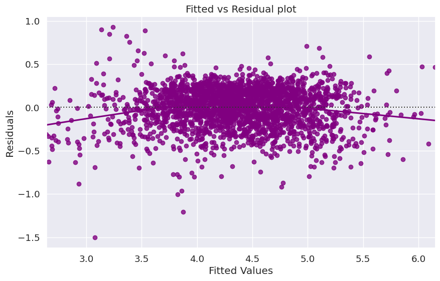

```python
# Plotting the fitted values vs residuals
sns.residplot(data=df_pred, x="Fitted Values", y="Residuals", color="purple", lowess=True)
plt.xlabel("Fitted Values")
plt.ylabel("Residuals")
plt.title("Fitted vs Residual plot")
plt.show()
```

#### Observations for Test of Linearity and Independence

**Random Distribution:** Residuals are scattered randomly around the horizontal axis, indicating randomness in error distribution.

**No Apparent Patterns:** The absence of patterns or systematic structures suggests linearity in the relationship between predictors and the dependent variable.

**Independence of Errors:** Since residuals do not follow a pattern, it suggests that the errors are independent of each other, which is a crucial assumption for linear regression models.

### 4. Test for Normality

**Purpose:** To ensure residuals are normally distributed for reliable coefficient estimates and confidence intervals.

**Assessment:** Use histograms, Q-Q plots, and Shapiro-Wilk test to examine residual distribution.

**Resolution:** If normality is violated, consider applying log, exponential, or arcsinh transformations.

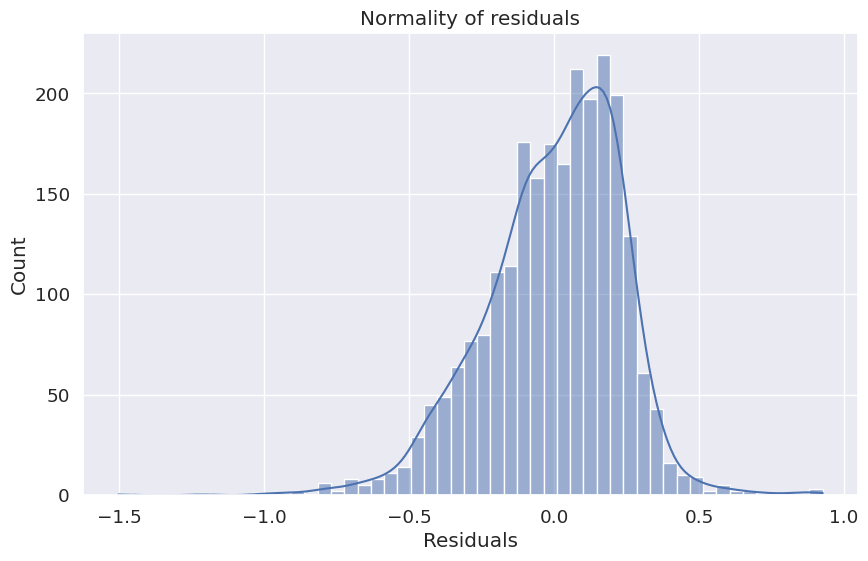

```python
# Test for Normality of Residuals using Histogram
sns.histplot(data=df_pred, x="Residuals", kde=True)
plt.title("Normality of residuals")
plt.show()
```

#### Observations:

- The histogram do show bell shape, but distribution is slightly left skewed.
- We will now test for normality using **Q-Q plot**.

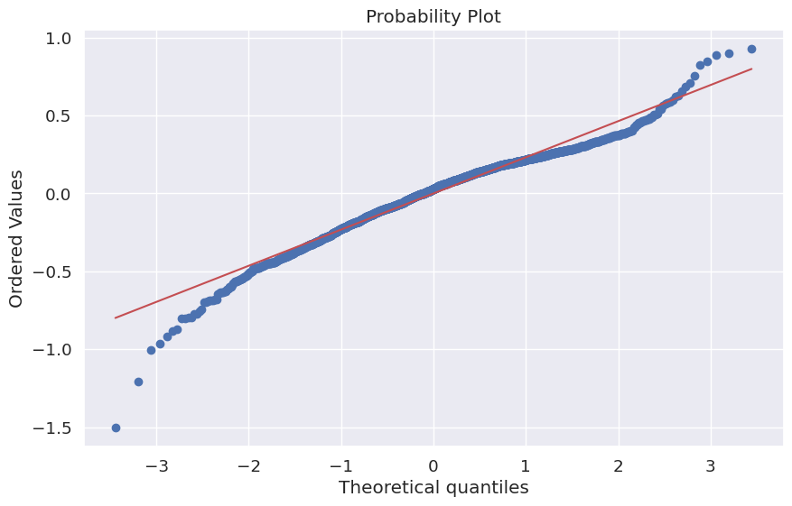

```python
# Import necessary libraries
import pylab
import scipy.stats as stats

# Q-Q plot
stats.probplot(df_pred["Residuals"], dist="norm", plot=pylab)
plt.show()
```

#### Observations:

- The residuals more or less follow a straight line except for the tails.
- Next we will check the results of the Shapiro-Wilk test.

```python
ttest, p_value = stats.shapiro(df_pred["Residuals"])
print(f'P-value returned by Shapiro-Wilk test is {p_value}.')
```

```
P-value returned by Shapiro-Wilk test is 1.2969799215209546e-21.
```

#### Observations from Shapiro-Wilk Test:

- The test yields a p-value well below 0.05, leading to the **rejection of the null hypothesis** and indicating that the **residuals are not normally distributed**.
- For practical purposes, the residual distribution can be **considered approximately normal, satisfying the normality assumption for the model**.

### 5. Test for Homoscedasticity

**Homoscedasticity ($H_0$):** implies that residuals exhibit constant variance across the regression line.

**Heteroscedasticity ($H_a$):** refers to a situation where residuals' variance is not constant.

**Importance of the Test:** Heteroscedasticity often arises due to outliers, leading to unreliable standard errors.

**Assessment Methods:**

- Residuals versus fitted values plots help detect homoscedasticity; non-random patterns suggest heteroscedasticity.
- The Goldfeld-Quandt test, where a p-value > 0.05 supports homoscedastic residuals.

**Remediation:** Address heteroscedasticity by incorporating key variables or applying data transformations.

```python
# Import necessary libraries
import statsmodels.stats.api as sms
from statsmodels.compat import lzip

# Use Goldfeldquandt test to prove the hypothesis
name = ["F statistic", "p-value"]
test = sms.het_goldfeldquandt(df_pred["Residuals"], X_train3)
lzip(name, test)
```

```
[('F statistic', 1.0648757500800878), ('p-value', 0.13825250199575034)]
```

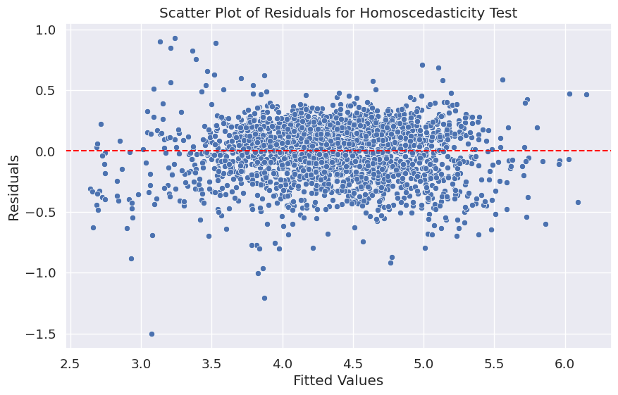

```python
#Plot scatter plot to visualize the Homoscadesticity
sns.scatterplot(x=df_pred['Fitted Values'], y=df_pred['Residuals'])
plt.axhline(y=0, color='red', linestyle='--') # Horizontal line for reference
plt.xlabel('Fitted Values')
plt.ylabel('Residuals')
plt.title('Scatter Plot of Residuals for Homoscedasticity Test')
plt.show()
```

#### Observations for Homoscedasticity Test

- As per **goldfeldquandt** test returns **p-value** of **0.138**, which **fails to reject the null hypothesis**.
- The Residuals, when visualized, suggest there is **no evidence of Heteroscedasticity**.
- Therefore, **we assume that the Homoscedasticity assumption is satisfied** and we will continue using the olsmodel3 as our final model.

## Final Model

### Final Model Summary

```python
# Create final OLS model using the processed datasets.
olsmodel_final = sm.OLS(y_train, X_train3).fit()
print(olsmodel_final.summary())
```

```
                              OLS Regression Results
=================================================================================
Dep. Variable:     normalized_used_price   R-squared:                       0.838
Model:                               OLS   Adj. R-squared:                  0.837
Method:                    Least Squares   F-statistic:                     1556.
Date:                   Thu, 01 Feb 2024   Prob (F-statistic):               0.00
Time:                           23:51:38   Log-Likelihood:                 70.534
No. Observations:                   2417   AIC:                            -123.1
Df Residuals:                       2408   BIC:                            -70.96
Df Model:                              8
Covariance Type:               nonrobust
========================================================================================
                           coef    std err          t      P>|t|      [0.025      0.975]
----------------------------------------------------------------------------------------
const                    1.2258      0.045     27.486      0.000       1.138       1.313
screen_size              0.0433      0.001     28.862      0.000       0.040       0.046
4g                       0.0365      0.015      2.421      0.016       0.007       0.066
main_camera_mp           0.0188      0.001     14.000      0.000       0.016       0.021
selfie_camera_mp         0.0133      0.001     12.514      0.000       0.011       0.015
ram                      0.0156      0.004      3.618      0.000       0.007       0.024
days_used             6.346e-05   3.05e-05      2.084      0.037    3.75e-06       0.000
normalized_new_price     0.4255      0.011     39.450      0.000       0.404       0.447
device_age              -0.0193      0.004     -4.486      0.000      -0.028      -0.011
==============================================================================
Omnibus:                      222.889   Durbin-Watson:                   1.914
Prob(Omnibus):                  0.000   Jarque-Bera (JB):              426.179
Skew:                          -0.614   Prob(JB):                     2.86e-93
Kurtosis:                       4.650   Cond. No.                     6.79e+03
==============================================================================

Notes:
[1] Standard Errors assume that the covariance matrix of the errors is correctly specified.
[2] The condition number is large, 6.79e+03. This might indicate that there are
strong multicollinearity or other numerical problems.
```

```python
# checking final model performance on train set (seen 70% data)
print("Training Performance:\n")
olsmodel_final_train_perf = model_performance_regression(olsmodel_final, X_train3, y_train)
olsmodel_final_train_perf
```

```
Training Performance:
```

|  | RMSE | MAE | R-squared | Adj. R-squared | MAPE |
| --- | --- | --- | --- | --- | --- |
| 0 | 0.235011 | 0.184164 | 0.837889 | 0.837283 | 4.417875 |

```python
# checking final model performance on test set (seen 30% data)
print("Test Performance:\n")
olsmodel_final_test_perf = model_performance_regression(olsmodel_final, X_test3, y_test)
olsmodel_final_test_perf
```

```
Test Performance:
```

|  | RMSE | MAE | R-squared | Adj. R-squared | MAPE |
| --- | --- | --- | --- | --- | --- |
| 0 | 0.238672 | 0.184313 | 0.842064 | 0.84068 | 4.491491 |

### Final model observations:

- The model accounts for approximately **84%** of the variance, indicating **strong explanatory power**.
- Comparable train and test RMSE and MAE values suggest that **overfitting is not a concern**.
- A MAPE of **4.5%** on the test set implies that the model's price predictions for used devices are accurate to within a narrow margin.
- Overall, the model is robust and suitable for both prediction and inferential analysis.

## Appendix: Detailed Exploratory Data Analysis (EDA)

### Univariate Analysis - Categorical Columns

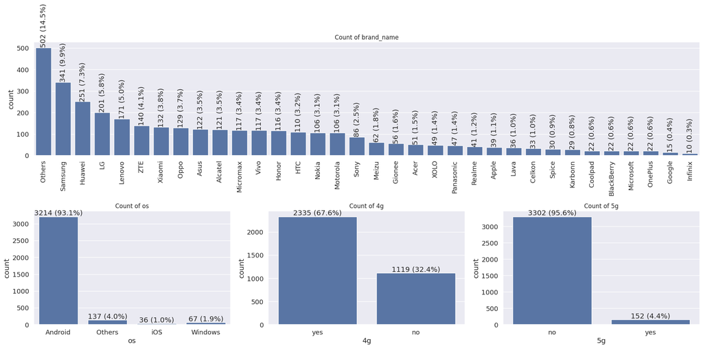

```python
#Create plots for categorical values such as brand_name, os, 4g and 5g.
plot_categorical(uddf)
```

#### Observatons for Categorical Variables:

**brand_name:**

- Consists of 34 unique brands.
- 'Others' is the most frequent category with 502 devices (15%), suggesting a wide variety of less common brands.
- Samsung, Huawei, LG and Lenovo are top brands for user phones contributing to about 28% of the given dataset combined.

**os:**

- 4 unique operating systems with 'Android' being the most dominant with 3214 devices (**93.1%**) running on it.
- This dominance may indicate a market preference or a larger availability of Android devices.

**4g:**

- Binary variable indicating the presence of 4G connectivity.
- Majority of devices support 4G, which is consistent with modern telecommunications standards.

**5g:**

- Binary variable indicating the presence of 5G connectivity.
- Most devices do not support 5G, possibly due to the dataset's timeline or the nascent adoption of 5G during the data collection period.

### Univariate Analysis - Numerical Columns

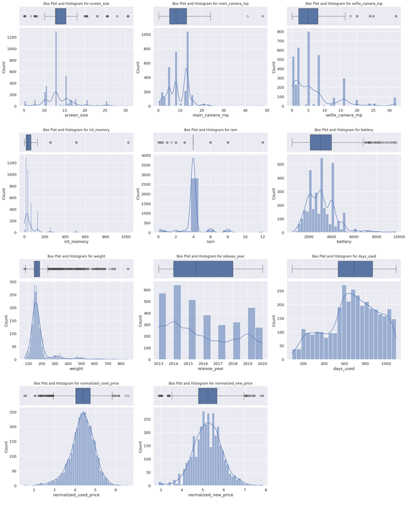

```python
#Create plots for all numerical (float64 and int64) columns
plot_numerical(uddf)
```

#### Observations from Numerical Columns:

**screen_size:**

- Ranges from 5.08 to 30.71 cm.
- Mean screen size is around 13.71 cm, indicating that most devices have a moderate screen size, suitable for general use.
- Box plot suggests that about 75% devices have screen size smaller than 15 cm.

**main_camera_mp:**

**selfie_camera_mp:**

- Ranges from 0 to 32 MP, with a mean of about 6.55 MP.
- The presence of 0 MP may indicate devices without a front camera or data entry issues.

**int_memory:**

- Ranges from 0.01 GB to 1024 GB, with a mean of about 54.57 GB.
- The range suggests a mix of older devices with low memory and newer, high-end devices.

**ram:**

- Ranges from 0.02 GB to 12 GB, with most devices having 4 GB of RAM (81.5%.
- Indicates that many devices are likely to deliver moderate performance suitable for everyday tasks.

**battery:**

- Ranges from 500 mAh to 9720 mAh, with a mean of about 3133 mAh.
- Reflects a wide variety of devices, from low-end to high-capacity batteries.

**weight:**

- Ranges from 69 g to 855 g, with a mean weight of around 182.75 g.
- The variation in weight indicates a diverse set of devices, from lightweight to more robust models.

**release_year:**

**days_used:**

- Ranges from 91 to 1094 days.
- Reflects varying degrees of usage, from fairly new devices to those that have been used for a longer time.

**normalized_used_price:**

- Ranges approximately from 1.54 to 6.62.
- The prices are normalized, showing a relative scale instead of actual price figures.
- The distribution of Normalized used price is mostly normal

**normalized_new_price:**

- Ranges approximately from 2.90 to 7.85.
- Similar to used prices, these are normalized figures, reflecting a relative price scale.

### Bivariate Analysis - Finding Correlation

The heatmap chart presented below illustrates the correlations among numerical variables in the provided dataset of used devices.

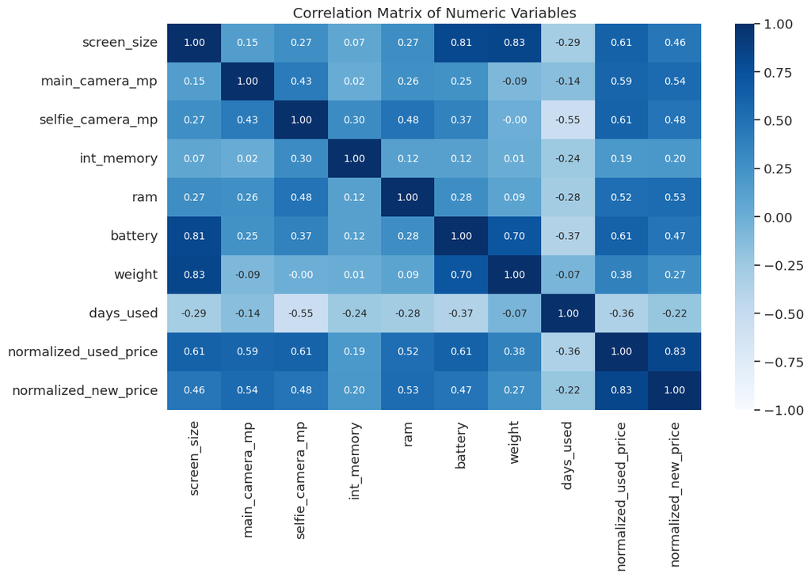

```python
# Select numeric columns from the dataset
numeric_columns = uddf.select_dtypes(include=np.number).columns.tolist()

# Remove the 'release_year' column as it represents temporal data and may not be relevant for correlation analysis.
numeric_columns.remove("release_year")

# Set up the figure size for the heatmap
plt.figure(figsize=(12, 7))

# Generate a heatmap for the correlation matrix of numerical variables
sns.heatmap(uddf[numeric_columns].corr(),
            annot=True,   # - annot=True displays the correlation coefficients
            vmin=-1,      # - vmin and vmax set the range of the colormap
            vmax=1,
            fmt=".2f",    # - fmt specifies the string formatting for annotation texts
            cmap="Blues", # - cmap="Blues" sets the color scheme
            annot_kws={"size": 10}) # - annot_kws allows customization of annotation texts (e.g., size)

# Add a title to the heatmap for better context
plt.title('Correlation Matrix of Numeric Variables')

# Display the heatmap
plt.show()
```

#### Observations:

**Correlation with normalized_used_price:**

**Multicollinearity Concerns:**

- **screen_size** and **weight** have a very high positive correlation (0.83), suggesting multicollinearity. It's common for larger devices to weigh more, but this relationship might inflate the coefficients in a regression model.
- **screen_size** and **battery** also show a high correlation (0.81) which is likely due to larger phones may demand more power, a potential candidate for multicollinearity.
- **battery** and **weight** shows high correlation (0.70), which is expected as larger batteries may weigh more.

**Other Observations:**

- It's also worth noting the negative correlation of **days_used** with **normalized_used_price**, indicating that devices used for longer periods tend to decrease in value.

Given these observations, further analysis and model building should carefully consider the potential multicollinearity, especially when including features like **screen_size**, **weight**, **battery**, and **days_used**.